# Modelling depression with SHARE data

Part 2: Data analysis

Lara Lusa and Marianne Huebner

28 July 2021

# Outline

1. Research question and statistical analysis plan
2. Initial data analysis
3. Statistical modeling

All R code can be shown by selecting Code/Show all code in the top right corner of the document, or individual chunks can be displayed or hidden using the Code/Hidden buttons that appear on the right of the text.

```r
knitr::opts_chunk$set(echo = TRUE, cache = FALSE, message=FALSE, warning= FALSE,
                      size="tiny", attr.output='style="max-height: 300px;"')
library(knitr) #markdown document
library(ggplot2) #graphs
library(dplyr) #data manipulation
library(lubridate) #dates
library(magrittr) #for the pipe operator
library(reshape2) #to transform data (for example: long to wide format in longitudinal data)
library(tidyr) #data transformation
library(data.table) #to produce wide format data using multiple time varying variables dcast
library(finalfit) #output of regression models
library(rms) #for using restricted cubic splines in regression models
library(naniar) ## for missing data
library(forcats) #tools for working with categorical variables
library(summarytools) #summary tables
library(kableExtra) #summary tables
library(skimr) #summary tables
library(tableone) #summary tables
library(here) #to read/write files without specifying the full paths
library(DescTools)#descriptive tools
library(corrplot) #correlation matrix
library(gmodels) #for cross-tabulations
library(vcd) #categorical variables
```

```r
color <- function(x, color="red") {
  if (knitr::is_latex_output()) {
    sprintf("\\textcolor{%s}{%s}", color, x)
  } else if (knitr::is_html_output()) {
    sprintf("<span style='color: %s;'>%s</span>", color,
      x)
  } else x
}

#can be used inline to change the color of the text, default is red
#`r color("try red color")`, `r color("try blue color", "blue")`


#to reduce the fontsize of the chunks
def.chunk.hook  <- knitr::knit_hooks$get("chunk")
knitr::knit_hooks$set(chunk = function(x, options) {
  x <- def.chunk.hook(x, options)
  ifelse(options$size != "normalsize", paste0("\n \\", options$size,"\n\n", x, "\n\n \\normalsize"), x)
})



#function that displays the OR, CI and p-values from a logistic model
get.OR2<-function(my.mod, names.var=NULL){
  my.coef <- summary(my.mod)$coef
  tmp<-cbind(exp(my.coef[,1]), exp(my.coef[,1]-qnorm(.975)*my.coef[,2]),  exp(my.coef[,1]+qnorm(.975)*my.coef[,2]), my.coef[,4])
  dimnames(tmp)[[2]]<-c("OR", "95\\% CI LL",  "95\\% CI UL", "P-value")
  if(!is.null(names.var))   dimnames(tmp)[[1]]<-names.var else dimnames(tmp)[[1]] <- dimnames(my.coef)[[1]]
  tmp
}
```

# 1 Research question and statistical analysis plan

**Primary aim:** Identify the risk factors for depression at first interview (cross-sectional), with special emphasis on the effect of age and how it differs between men and women and in different European geographical regions.

**Secondary aim:** Identify how the individual depressive symptoms of the euroD depression score are associated with the risk factors.

**Data:** Data from first SHARE interview.

**Outcome variable:** Presence of depression is defined as 4 or more points in the EURO-D questionnaire;

- Result from EURO-D questionnaire
  - score (`gv_health:eurod`)
  - dicotomized euroD (`gv_health:eurodcat`)

**Exclusion criteria:**

- SHARELIFE interview (Wave 3 or SHARELIFE in Wave 7 (`technical_variables:mn103_`, answer: Yes))
- presence of dementia or other serious mental impairments (`ph:ph006d16`, Alzheimer’s disease, dementia, organic brain syndrome, senility or any other serious memory impairment) at current interview or at any previous interview. As the variable was first introduced in wave 2, the participants that reported the condition in wave 2 were removed also from wave 1.
- age at first interview less than 50 at inclusion or unknown year of birth (all the interviews are removed)
- age at first interview more than 90 at inclusion
- subject with all missing values in the outcome variable `eurod`; for the cross-sectional part of the study: remove also those that having missing outcome at first measurement.

**Independent predictors**

A *pivotal variable* is a covariate that is considered to be strongly related with the outcome. This helps structure initial data analyses.

1. age (`cv_r:age_int`) - *pivotal variable*,
2. gender (`cv_r:gender`) - *pivotal variable*,
3. country (`cv_r:country`) - *pivotal variable*, countries were categorized in European **regions** (Northern Europe (Denmark and Sweden), Western Europe (Austria, Germany, France, the Netherlands, Switzerland, Belgium, Ireland and Luxembourg), Southern Europe (Spain, Italy, Greece, Portugal and Israel) and Eastern Europe (Czech Republic, Poland, Hungary, Slovenia, Estonia and Croatia).
4. education (`gv_isced:isced1997_r`) - to be further categorized in low (ISCED 1,2), medium (3,4), high(>=5), other (still in school, Other); new variable name: `education`
5. presence of important chronic disease in 3 categories (having ever being diagnosed with 0, 1, or 2 or more out of 6of the following diseases: heart attack (`ph:ph006d1`), high blood pressure (`ph:ph006d2`), stroke (`ph:ph006d4`), diabetes (`ph:ph006d5`), cancer (`ph:ph006d10`) ), lung (`ph:ph006d6`, combined with `ph:ph006d7` in wave 1 and 2); new variable name: `dis_chronic_pres`
6. BMI (`gv_health:bmi`)
7. physical activity (`br:br015_`): Sports or activities that are vigorous (4 categories)
8. smoking (`gv_health:cusmoke`), reported being a smoker at baseline/first interview.
9. living arrangement -> with partner/alone derived from `dn:dn014_`, to be transformed into married/with partner (“with partner”), widowed, separated, living alone (“alone”); note that also the `dn:dn014_` variable (Change in marital status) must be taken into the account when creating the new variable, as in longitudinal interviews the marital status is recorded only if some changes occurred.
10. Instrumental Activities of Daily Living (`gv_health:IADL2`, dicotomized version of the index)

**Additional variables to download for further data cleaning/checking**

- weight (`ph:ph012_`)
- height (`ph:ph013_`)
- questionnaire version (`technical_variables:mn101_`, baseline or longitudinal).
- sharelife interview (`technical_variables:mn103_`, only in wave 7)
- For smoking status in `br` module:
  - `br001_` (ever smoked daily for at least a year),
  - `br002_` (smokes at present time - asked only if positive answer to `br001_`),
- Single items that compose the EURO-D score form the `gv_health` module
  1. `eurod1` depressed mood
  2. `eurod2` pessimism
  3. `eurod3` wishing death
  4. `eurod4` guilt
  5. `eurod5` sleep
  6. `eurod6` interest
  7. `eurod7` irritability
  8. `eurod8` appetite
  9. `eurod9` fatigue
  10. `eurod10` concentration
  11. `eurod11` enjoyment
  12. `eurod12` tearfulness
- Information about interview from `cv_r` module: - `int_year` (year of interview), - `int_month` (month of interview), - `firstwave` (first wave when included), - `mobirth` (month of birth), - `yrbirth` (year of birth)
- Mental health history from `mh` module:
  - `mh018_`: ever suffering from depression for more than 14 days
  - `mh019_`: age at first diagnosis of depression
  - `mh020_`: ever treated for depression
  - `mh021_`: ever admitted to hospital because of depression

**Statistical methods**

A logistic regression model will be used to investigate the association between the risk factors and depression. The shape of the association between age and the probability of depression will be investigated with restricted cubic splines and compared to models with a linear effect of age. Two-way interactions between age, region of residence, and gender will be included in all models (“unadjusted analysis”), and models with additional risk factors will be considered (“adjusted analysis”).

The secondary research question is to analyze the single items that constitute the euroD score; the secondary analyses and results are described in **Part 3**.

# 2 Initial data analysis

The purpose of initial data analysis (IDA) is to study data properties that might impact the statistical modeling. We split this into three parts, missing, data, univariate and multivariate analyses.

```r
source("scripts/f_readRShare.r")
load(file="out/DepressionSHARE.Rdata")
#load(file=here::here("out/DepressionSHARE.Rdata"))
```

The analysis included 108927 unique participants from 20 countries.

## 2.1 Missing data

Overall, the number of missing values was low.

### 2.1.1 Outcome missingness

Outcome was missing for n=2147 participants (2 %). The characteristics of these participants were compared to those of participants with complete outcome value.

```r
 #share.data.first.interview <- share.data.first.interview  %>% mutate(eurod_cat_f = )


#using skimr package
my.summary.skim <- share.data.first.interview %>% select( c("Wave", "gender", "region", "age_int", "age_int_cat", "education_imp", "bmi_imp", "living_arrangement",  "pa_vig" ,  "cusmoke_imp", "dis_chronic_pres", "iadl2", "eurodcat_imp" )) %>% mutate(eurodNA = as.factor(is.na(eurodcat_imp))) %>%
    group_by(eurodNA) %>% skim()


my.data <- share.data.first.interview %>% mutate(eurodNA = factor(is.na(eurodcat_imp))) %>% select( c("Wave", "gender", "region", "age_int", "age_int_cat", "education_imp", "bmi_imp", "living_arrangement",  "pa_vig" ,  "cusmoke_imp", "dis_chronic_pres", "iadl2", "eurodNA"))#, "eurodcat_imp" ))

#using tableone package
my.summary.tableone <- CreateTableOne(strata = "eurodNA" , data = my.data)
print(my.summary.tableone, formatOptions = list(big.mark = ","))
```

```
##                                        Stratified by eurodNA
##                                         FALSE           TRUE           p
##   n                                     106,780         2,147
##   Wave (%)                                                             <0.001
##      Wave 1                               25460 (23.8)    408 ( 19.0)
##      Wave 2                               14211 (13.3)    247 ( 11.5)
##      Wave 4                               35126 (32.9)    698 ( 32.5)
##      Wave 5                               20984 (19.7)    339 ( 15.8)
##      Wave 6                               10990 (10.3)    455 ( 21.2)
##      Wave 7                                   9 ( 0.0)      0 (  0.0)
##   gender = Female (%)                     58000 (54.3)    932 ( 43.4)  <0.001
##   region (%)                                                           <0.001
##      Northern                             11521 (10.8)    136 (  6.3)
##      Western                              43632 (40.9)    774 ( 36.1)
##      Southern                             23475 (22.0)    564 ( 26.3)
##      Eastern                              28152 (26.4)    673 ( 31.3)
##   age_int (mean (SD))                     63.78 (9.62)  66.32 (10.99)  <0.001
##   age_int_cat (%)                                                      <0.001
##      50-59                                42136 (39.5)    739 ( 34.4)
##      60-69                                34481 (32.3)    585 ( 27.2)
##      70-80                                23696 (22.2)    541 ( 25.2)
##      80+                                   6467 ( 6.1)    282 ( 13.1)
##   education_imp (%)                                                    <0.001
##      Low                                  44998 (42.4)    988 ( 51.8)
##      Medium                               39052 (36.8)    591 ( 31.0)
##      High                                 21611 (20.4)    313 ( 16.4)
##      Other                                  460 ( 0.4)     17 (  0.9)
##   bmi_imp (mean (SD))                     26.82 (4.56)  26.49 (4.65)    0.005
##   living_arrangement = Living alone (%)   29524 (27.7)    436 ( 22.9)  <0.001
##   pa_vig (%)                                                           <0.001
##      More than once a week                37986 (35.6)    407 ( 24.7)
##      Once a week                          14910 (14.0)    138 (  8.4)
##      One to three times a month           10194 ( 9.6)    110 (  6.7)
##      Hardly ever, or never                43465 (40.8)    991 ( 60.2)
##   cusmoke_imp = Yes (%)                   21066 (19.8)    296 ( 17.9)   0.068
##   dis_chronic_pres (%)                                                 <0.001
##      0                                    50768 (47.6)    736 ( 43.9)
##      1                                    36108 (33.8)    544 ( 32.5)
##      2+                                   19813 (18.6)    396 ( 23.6)
##   iadl2 = 1+ iadl limitations (%)         15945 (14.9)    613 ( 37.4)  <0.001
```

[output cut: 27 more lines]

```
##      Other
##   bmi_imp (mean (SD))
##   living_arrangement = Living alone (%)
##   pa_vig (%)
##      More than once a week
##      Once a week
##      One to three times a month
##      Hardly ever, or never
##   cusmoke_imp = Yes (%)
##   dis_chronic_pres (%)
##      0
##      1
##      2+
##   iadl2 = 1+ iadl limitations (%)
##   eurodNA = TRUE (%)
```

Missing outcome was more common in males, in older, less educated, less physically active, with more comorbidities and iadl limitations, living with a partner, non-smokers. Also, wave 6 had more missing values, while overall the Northern region had fewer missing values.

To investigate the predictors of missing outcome we fitted univiariate and multivariate logistic regression models, using the covariates from the research question.

```r
#age modelled using restricted cubic splines
explanatory = c("age_int_cat",  "gender", "region", "education_imp", "bmi_imp", "living_arrangement", "pa_vig", "cusmoke_imp", "dis_chronic_pres", "iadl2")
dependent = "eurodNA"



my.mod <- my.data %>%
    finalfit(dependent, explanatory, confint_type = "default", metrics = TRUE)



knitr::kable(my.mod[[1]], row.names=FALSE, align=c("l", "l", "r", "r", "r", "r"))
```

Dependent: eurodNA

FALSE

TRUE

OR (univariable)

OR (multivariable)

age_int_cat

50-59

42136 (98.3)

739 (1.7)

60-69

34481 (98.3)

585 (1.7)

0.97 (0.87-1.08, p=0.552)

0.83 (0.72-0.95, p=0.006)

70-80

23696 (97.8)

541 (2.2)

1.30 (1.16-1.46, p<0.001)

0.93 (0.80-1.08, p=0.332)

80+

6467 (95.8)

282 (4.2)

2.49 (2.16-2.86, p<0.001)

1.24 (1.02-1.51, p=0.029)

gender

Male

48780 (97.6)

1215 (2.4)

Female

58000 (98.4)

932 (1.6)

0.65 (0.59-0.70, p<0.001)

0.50 (0.45-0.56, p<0.001)

region

Northern

11521 (98.8)

136 (1.2)

Western

43632 (98.3)

774 (1.7)

1.50 (1.25-1.81, p<0.001)

1.50 (1.18-1.91, p=0.001)

Southern

23475 (97.7)

564 (2.3)

2.04 (1.69-2.46, p<0.001)

2.41 (1.88-3.09, p<0.001)

Eastern

28152 (97.7)

673 (2.3)

2.03 (1.68-2.44, p<0.001)

2.66 (2.09-3.39, p<0.001)

education_imp

Low

44998 (97.9)

988 (2.1)

Medium

39052 (98.5)

591 (1.5)

0.69 (0.62-0.76, p<0.001)

0.86 (0.75-0.97, p=0.016)

High

21611 (98.6)

313 (1.4)

0.66 (0.58-0.75, p<0.001)

0.91 (0.78-1.07, p=0.257)

Other

460 (96.4)

17 (3.6)

1.68 (1.03-2.74, p=0.037)

2.09 (1.19-3.67, p=0.010)

bmi_imp

Mean (SD)

26.8 (4.6)

26.5 (4.6)

0.98 (0.97-0.99, p=0.005)

0.97 (0.95-0.98, p<0.001)

living_arrangement

Living with partner

77189 (98.1)

1464 (1.9)

Living alone

29524 (98.5)

436 (1.5)

0.78 (0.70-0.87, p<0.001)

0.65 (0.57-0.74, p<0.001)

pa_vig

More than once a week

37986 (98.9)

407 (1.1)

Once a week

14910 (99.1)

138 (0.9)

0.86 (0.71-1.05, p=0.139)

0.86 (0.70-1.06, p=0.150)

One to three times a month

10194 (98.9)

110 (1.1)

1.01 (0.81-1.24, p=0.948)

0.94 (0.75-1.17, p=0.559)

Hardly ever, or never

43465 (97.8)

991 (2.2)

2.13 (1.89-2.39, p<0.001)

1.64 (1.43-1.87, p<0.001)

cusmoke_imp

No

85494 (98.4)

1354 (1.6)

Yes

21066 (98.6)

296 (1.4)

0.89 (0.78-1.01, p=0.064)

0.89 (0.77-1.02, p=0.104)

dis_chronic_pres

0

50768 (98.6)

736 (1.4)

1

36108 (98.5)

544 (1.5)

1.04 (0.93-1.16, p=0.499)

0.87 (0.77-0.99, p=0.034)

2+

19813 (98.0)

396 (2.0)

1.38 (1.22-1.56, p<0.001)

0.85 (0.73-0.98, p=0.027)

iadl2

No iadl limitations

90801 (98.9)

1028 (1.1)

1+ iadl limitations

15945 (96.3)

613 (3.7)

3.40 (3.07-3.76, p<0.001)

2.95 (2.61-3.34, p<0.001)

```r
knitr::kable(my.mod[[2]], row.names=FALSE, col.names="")
```

| Number in dataframe = 108927, Number in model = 105548, Missing = 3379, AIC = 14689, C-statistic = 0.715, H&L = Chi-sq(8) 19.20 (p=0.014) |
| --- |

### 2.1.2 Covariates missingness

We repeated the analysis for missingness for the covariates needed for the analysis (missing indicates any missing value in the covariates, the analysis is performed only on subjects with non-missing outcomes ).

```r
my.data <- share.data.first.interview %>% filter(!is.na(eurodcat_imp)) %>% select( c("Wave", "gender", "region", "age_int", "age_int_cat", "education_imp", "bmi_imp", "living_arrangement",  "pa_vig" ,  "cusmoke_imp", "dis_chronic_pres", "iadl2"))  %$% mutate(., Missing=!complete.cases(.))


#using tableone package
my.summary.tableone <- CreateTableOne(strata = "Missing" , data = my.data)
print(my.summary.tableone, formatOptions = list(big.mark = ","))
```

```
##                                        Stratified by Missing
##                                         FALSE           TRUE           p
##   n                                     104,069         2,711
##   Wave (%)                                                             <0.001
##      Wave 1                               25069 (24.1)    391 ( 14.4)
##      Wave 2                               13710 (13.2)    501 ( 18.5)
##      Wave 4                               33871 (32.5)   1255 ( 46.3)
##      Wave 5                               20604 (19.8)    380 ( 14.0)
##      Wave 6                               10807 (10.4)    183 (  6.8)
##      Wave 7                                   8 ( 0.0)      1 (  0.0)
##   gender = Female (%)                     56182 (54.0)   1818 ( 67.1)  <0.001
##   region (%)                                                           <0.001
##      Northern                             11259 (10.8)    262 (  9.7)
##      Western                              42632 (41.0)   1000 ( 36.9)
##      Southern                             22748 (21.9)    727 ( 26.8)
##      Eastern                              27430 (26.4)    722 ( 26.6)
##   age_int (mean (SD))                     63.69 (9.57)  67.19 (11.08)  <0.001
##   age_int_cat (%)                                                      <0.001
##      50-59                                41304 (39.7)    832 ( 30.7)
##      60-69                                33709 (32.4)    772 ( 28.5)
##      70-80                                23006 (22.1)    690 ( 25.5)
##      80+                                   6050 ( 5.8)    417 ( 15.4)
##   education_imp (%)                                                    <0.001
##      Low                                  43811 (42.1)   1187 ( 57.8)
##      Medium                               38478 (37.0)    574 ( 28.0)
##      High                                 21336 (20.5)    275 ( 13.4)
##      Other                                  444 ( 0.4)     16 (  0.8)
##   bmi_imp (mean (SD))                     26.82 (4.56)  26.89 (4.76)    0.668
##   living_arrangement = Living alone (%)   28442 (27.3)   1082 ( 40.9)  <0.001
##   pa_vig (%)                                                           <0.001
##      More than once a week                37346 (35.9)    640 ( 25.7)
##      Once a week                          14613 (14.0)    297 ( 11.9)
##      One to three times a month           10003 ( 9.6)    191 (  7.7)
##      Hardly ever, or never                42107 (40.5)   1358 ( 54.6)
##   cusmoke_imp = Yes (%)                   20624 (19.8)    442 ( 17.7)   0.011
##   dis_chronic_pres (%)                                                  0.001
##      0                                    49616 (47.7)   1152 ( 44.0)
##      1                                    35168 (33.8)    940 ( 35.9)
##      2+                                   19285 (18.5)    528 ( 20.2)
##   iadl2 = 1+ iadl limitations (%)         15169 (14.6)    776 ( 29.0)  <0.001
```

[output cut: 27 more lines]

```
##      Other
##   bmi_imp (mean (SD))
##   living_arrangement = Living alone (%)
##   pa_vig (%)
##      More than once a week
##      Once a week
##      One to three times a month
##      Hardly ever, or never
##   cusmoke_imp = Yes (%)
##   dis_chronic_pres (%)
##      0
##      1
##      2+
##   iadl2 = 1+ iadl limitations (%)
##   Missing = TRUE (%)
```

Participants with missing covariates: 2711

Missing values in the covariates were more common in females, in Southern region, in older, less educated, less physically active, with more comorbidities and iadl limitations, living alone. Waves 2 and 4 had more missing values.

### 2.1.3 Comparing complete and incomplete cases

```r
my.data <- share.data.first.interview %>%  select( c("Wave", "gender", "region", "age_int", "age_int_cat", "education_imp", "bmi_imp", "living_arrangement",  "pa_vig" ,  "cusmoke_imp", "dis_chronic_pres", "iadl2", "eurodcat_imp"))  %$% mutate(., Missing=factor(!complete.cases(.)))


#using tableone package
my.summary.tableone <- CreateTableOne(strata = "Missing" , data = my.data)
print(my.summary.tableone, formatOptions = list(big.mark = ","))
```

```
##                                        Stratified by Missing
##                                         FALSE           TRUE           p
##   n                                     104,069         4,858
##   Wave (%)                                                             <0.001
##      Wave 1                               25069 (24.1)    799 ( 16.4)
##      Wave 2                               13710 (13.2)    748 ( 15.4)
##      Wave 4                               33871 (32.5)   1953 ( 40.2)
##      Wave 5                               20604 (19.8)    719 ( 14.8)
##      Wave 6                               10807 (10.4)    638 ( 13.1)
##      Wave 7                                   8 ( 0.0)      1 (  0.0)
##   gender = Female (%)                     56182 (54.0)   2750 ( 56.6)  <0.001
##   region (%)                                                           <0.001
##      Northern                             11259 (10.8)    398 (  8.2)
##      Western                              42632 (41.0)   1774 ( 36.5)
##      Southern                             22748 (21.9)   1291 ( 26.6)
##      Eastern                              27430 (26.4)   1395 ( 28.7)
##   age_int (mean (SD))                     63.69 (9.57)  66.81 (11.04)  <0.001
##   age_int_cat (%)                                                      <0.001
##      50-59                                41304 (39.7)   1571 ( 32.3)
##      60-69                                33709 (32.4)   1357 ( 27.9)
##      70-80                                23006 (22.1)   1231 ( 25.3)
##      80+                                   6050 ( 5.8)    699 ( 14.4)
##   education_imp (%)                                                    <0.001
##      Low                                  43811 (42.1)   2175 ( 54.9)
##      Medium                               38478 (37.0)   1165 ( 29.4)
##      High                                 21336 (20.5)    588 ( 14.8)
##      Other                                  444 ( 0.4)     33 (  0.8)
##   bmi_imp (mean (SD))                     26.82 (4.56)  26.62 (4.69)    0.039
##   living_arrangement = Living alone (%)   28442 (27.3)   1518 ( 33.4)  <0.001
##   pa_vig (%)                                                           <0.001
##      More than once a week                37346 (35.9)   1047 ( 25.3)
##      Once a week                          14613 (14.0)    435 ( 10.5)
##      One to three times a month           10003 ( 9.6)    301 (  7.3)
##      Hardly ever, or never                42107 (40.5)   2349 ( 56.8)
##   cusmoke_imp = Yes (%)                   20624 (19.8)    738 ( 17.8)   0.002
##   dis_chronic_pres (%)                                                 <0.001
##      0                                    49616 (47.7)   1888 ( 43.9)
##      1                                    35168 (33.8)   1484 ( 34.5)
##      2+                                   19285 (18.5)    924 ( 21.5)
##   iadl2 = 1+ iadl limitations (%)         15169 (14.6)   1389 ( 32.2)  <0.001
```

[output cut: 29 more lines]

```
##   bmi_imp (mean (SD))
##   living_arrangement = Living alone (%)
##   pa_vig (%)
##      More than once a week
##      Once a week
##      One to three times a month
##      Hardly ever, or never
##   cusmoke_imp = Yes (%)
##   dis_chronic_pres (%)
##      0
##      1
##      2+
##   iadl2 = 1+ iadl limitations (%)
##   eurodcat_imp (mean (SD))
##   Missing = TRUE (%)
```

Per-analysis missingness was more common in females, in non-Nothern region, in older, less educated, in the least physically active, with more comorbidities and IADL limitations, living alone.

### 2.1.4 Item missingness

Number and percentage of missing values.

```r
share.data.first.interview %>%
  select(gender, region, age_int, weight, height_imp, bmi_imp, education_imp , pa_vig , cusmoke_imp,dis_chronic_pres, iadl2, living_arrangement, eurodcat_imp) %>%
   miss_var_summary() %>%
  gt::gt() %>%
    gt::cols_label(
    variable = "Variable",
    n_miss = "Missing (count)",
    pct_miss = "Missing (%)"
  ) %>%
  gt::fmt_number(
    columns = vars(pct_miss),
    decimals = 2
  )# Item (per variable) missingness
```

| Variable | Missing (count) | Missing (%) |
| --- | --- | --- |
| bmi_imp | 2551 | 2.34 |
| eurodcat_imp | 2147 | 1.97 |
| weight | 1791 | 1.64 |
| height_imp | 1342 | 1.23 |
| education_imp | 897 | 0.82 |
| pa_vig | 726 | 0.67 |
| cusmoke_imp | 717 | 0.66 |
| dis_chronic_pres | 562 | 0.52 |
| iadl2 | 540 | 0.50 |
| living_arrangement | 314 | 0.29 |
| gender | 0 | 0.00 |
| region | 0 | 0.00 |
| age_int | 0 | 0.00 |

Overall, the number of missing items at first interview is very small.

Graphical presentation of missing values (baseline wave, overall)

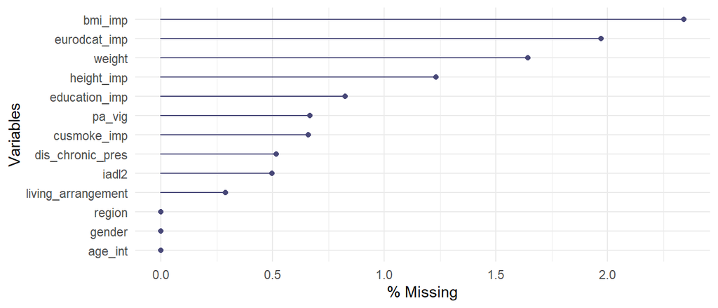

```r
share.data.first.interview %>%
  select(gender, region, age_int, weight, height_imp, bmi_imp, education_imp , pa_vig , cusmoke_imp,dis_chronic_pres, iadl2, living_arrangement, eurodcat_imp, eurodcat_imp) %>%
  gg_miss_var(show_pct = TRUE)
```

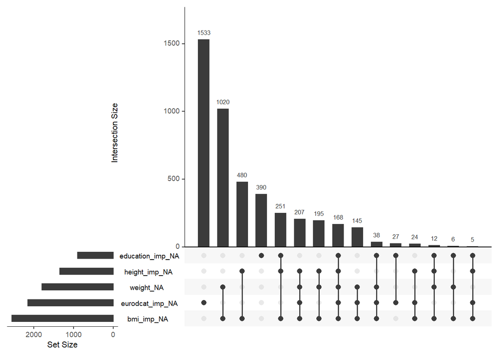

```r
share.data.first.interview %>%
         select(gender, region, age_int, weight, height_imp, bmi_imp, education_imp , pa_vig , cusmoke_imp,dis_chronic_pres, iadl2, living_arrangement, eurodcat_imp)  %>%
  gg_miss_upset()
```

Weight and BMI or height and BMI are missing together. Other than these there is no pattern of missingness.

```r
num.excluded.missing.outcome.first <- sum(is.na(share.data.first.interview$eurodcat_imp))
```

Number of records included after exclusion criteria: 108927.

Number of participants with missing outcomes: 2147.

```r
num.excluded.missing.covariates <- share.data.first.interview %>% filter(!is.na(eurodcat_imp)) %>%
         select(gender, region, age_int, bmi_imp, education_imp , pa_vig , cusmoke_imp,dis_chronic_pres, iadl2, living_arrangement) %>% complete.cases() %>% data.frame() %$% sum(!.)
```

Number of participants with incomplete explanatory variables (among those with complete outcome): 2711.

```r
num.analysis <- share.data.first.interview %>%
         select(gender, region, age_int, bmi_imp, education_imp , pa_vig , cusmoke_imp,dis_chronic_pres, iadl2, living_arrangement, eurodcat_imp) %>% complete.cases() %>% sum()
```

Number of subjects with complete data for the research question (all covariates available): 104069.

```r
#setting to factor the outcome
share.data.first.interview$eurodcat_imp_f <- as.factor(share.data.first.interview$eurodcat_imp)
```

Since the number of missing values was small, we decided to remove the participants with missing values in outcome or any of the covariates from the analysis. The descriptive statistics and analyses reported in the rest of the document refer to this reduced dataset and thus the study sample size was 104069.

```r
share.data.first.interview.model <- share.data.first.interview %>%
         select(mergeid, Wave, gender, region, country, age_int, age_int_cat, bmi_imp, education_imp , pa_vig , cusmoke_imp,dis_chronic_pres, iadl2, living_arrangement, eurodcat_imp, eurodcat_imp_f) %$% filter(., complete.cases(.))

share.data.first.interview.model <- left_join(share.data.first.interview.model, select(share.data.first.interview, c("mergeid", "eurod", "euro1", "euro2", "euro3", "euro4", "euro5", "euro6", "euro7", "euro7", "euro8", "euro9", "euro10", "euro11", "euro12" )), by="mergeid")
```

#### 2.1.4.1 Missingness of the EURO-D items

We explored also the missingness of the the items that constitute the EURO-D score

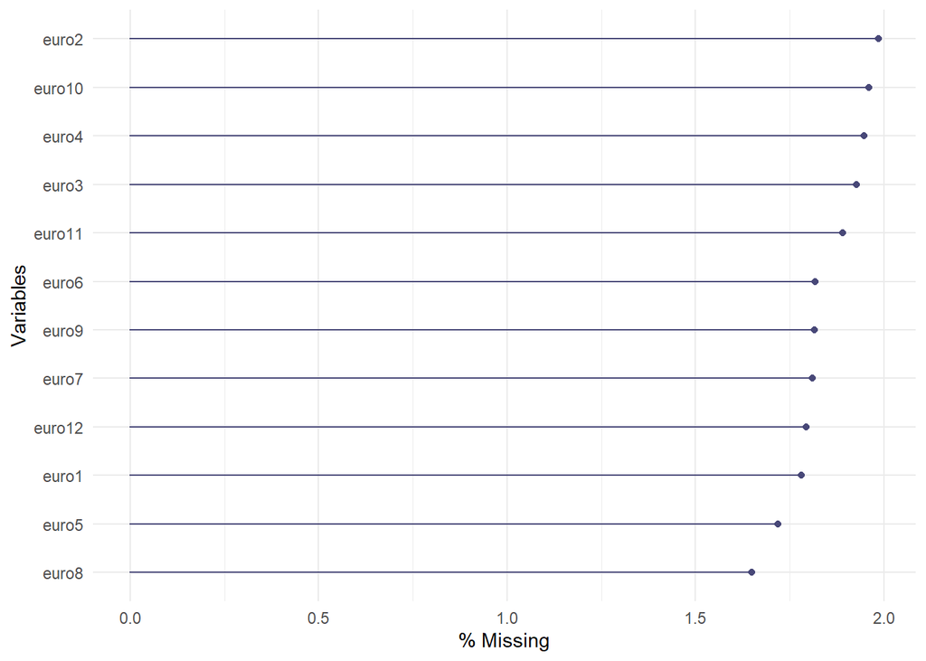

```r
share.data.first.interview %>%
     select(starts_with("euro") & !ends_with("_imp") & !ends_with("d") & !ends_with("cat")& !ends_with("f")) %>%
     gg_miss_var(show_pct = TRUE)
```

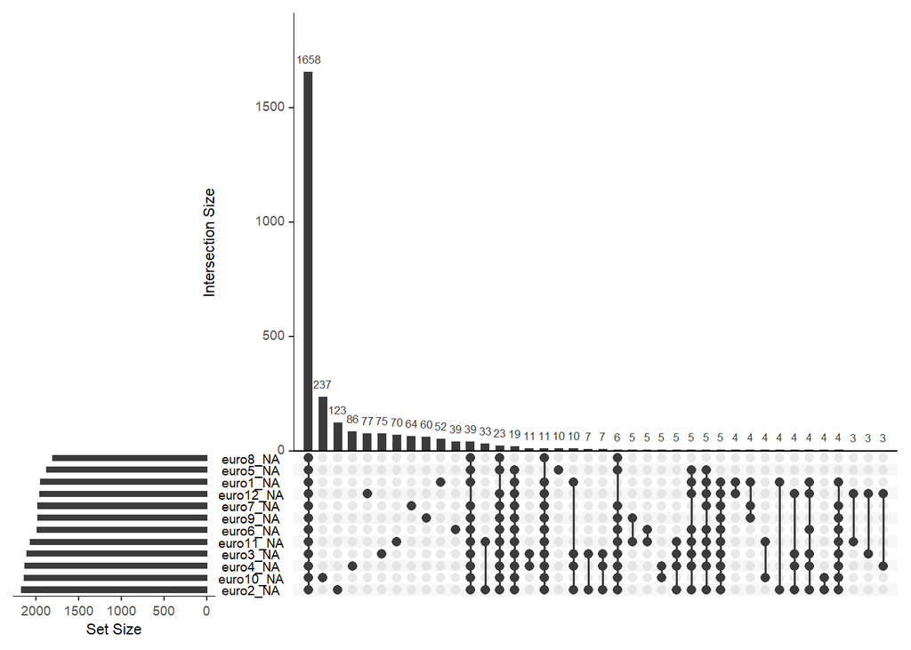

```r
share.data.first.interview %>%
     select(starts_with("euro") & !ends_with("_imp") & !ends_with("d") & !ends_with("cat")& !ends_with("f")) %>%
  gg_miss_upset(nsets=12)
```

The missingness of the items was also very low; the most common situation was that all items were missing, among individual items those more commonly missing were pessimism (euro2), concentration (euro10), guilt (euro4) and wishing death (euro3).

## 2.2 Univariate analyses

The overall characteristics of the participants included in the analysis are reported in the table below.

```r
s <-
    Hmisc::summaryM(
        age_int+ age_int_cat+  gender + education_imp +  bmi_imp + living_arrangement+  pa_vig +  cusmoke_imp +  dis_chronic_pres + iadl2 + region +  eurodcat_imp_f ~1 ,
        data = share.data.first.interview.model,
        overall = FALSE,
        test = FALSE
    )

Hmisc::html(
    s,
    caption = 'Baseline characteristics (overall)',
    exclude1 = TRUE,
    npct = 'both',
    digits = 3,
    prmsd = TRUE,
    brmsd = TRUE,
    msdsize = mu$smaller2
)
```

| Baseline characteristics (overall). | Baseline characteristics (overall). *N=104069* |
| --- | --- |
| age_int | 56.00 62.00 71.00 63.69 ± 9.57 |
| age_int_cat : 50-59 | 0.40 <sup>41304</sup>⁄<sub>104069</sub> |
| 60-69 | 0.32 <sup>33709</sup>⁄<sub>104069</sub> |
| 70-80 | 0.22 <sup>23006</sup>⁄<sub>104069</sub> |
| 80+ | 0.06 <sup>6050</sup>⁄<sub>104069</sub> |
| gender : Female | 0.54 <sup>56182</sup>⁄<sub>104069</sub> |
| education_imp : Low | 0.42 <sup>43811</sup>⁄<sub>104069</sub> |
| Medium | 0.37 <sup>38478</sup>⁄<sub>104069</sub> |
| High | 0.21 <sup>21336</sup>⁄<sub>104069</sub> |
| Other | 0.00 <sup>444</sup>⁄<sub>104069</sub> |
| bmi_imp | 23.81 26.22 29.30 26.82 ± 4.56 |
| living_arrangement : Living alone | 0.27 <sup>28442</sup>⁄<sub>104069</sub> |
| pa_vig : More than once a week | 0.36 <sup>37346</sup>⁄<sub>104069</sub> |
| Once a week | 0.14 <sup>14613</sup>⁄<sub>104069</sub> |
| One to three times a month | 0.10 <sup>10003</sup>⁄<sub>104069</sub> |
| Hardly ever, or never | 0.40 <sup>42107</sup>⁄<sub>104069</sub> |
| cusmoke_imp : Yes | 0.2 <sup>20624</sup>⁄<sub>104069</sub> |
| dis_chronic_pres : 0 | 0.48 <sup>49616</sup>⁄<sub>104069</sub> |
| 1 | 0.34 <sup>35168</sup>⁄<sub>104069</sub> |
| 2+ | 0.19 <sup>19285</sup>⁄<sub>104069</sub> |
| iadl2 : 1+ iadl limitations | 0.15 <sup>15169</sup>⁄<sub>104069</sub> |
| region : Northern | 0.11 <sup>11259</sup>⁄<sub>104069</sub> |
| Western | 0.41 <sup>42632</sup>⁄<sub>104069</sub> |
| Southern | 0.22 <sup>22748</sup>⁄<sub>104069</sub> |
| Eastern | 0.26 <sup>27430</sup>⁄<sub>104069</sub> |
| eurodcat_imp_f | 0.27 <sup>28012</sup>⁄<sub>104069</sub> |

*a* *b* *c* represent the lower quartile *a*, the median *b*, and the upper quartile *c* for continuous variables. *x ± s* represents X ± 1 SD.

```r
mylatex <- function (...) {
    o <- capture.output(latex(file = "", where = "!htbp", ...))
    # this will strip /all/ line-only comments; or if you're only
    #  interested in stripping the first such comment you could
    #  adjust accordingly
    o <- grep('^%', o, inv=T, value=T)
    cat(o, sep='\n')
}


#TEX TO EDIT THE TABLE FOR THE PAPER
tex.table <- latex(
    s, digits=2, what="%", file="out/OverallT1.tex")
```

Most participants were in the younger age group (50-60), had lower education (42%), were not smokers (80%), about half had at least one chronic disease, 15% had iadl limitations, there were slightly more women than men. The Western region had most participants (41%), the Northern the least (11%).

### 2.2.1 Graphical displays

#### 2.2.1.1 Numerical variables

```r
share.data.first.interview.model %>%
  select(c("age_int", "bmi_imp"))%>%
  Hmisc::describe(descript = "Numerical variables") %>%
  Hmisc::html(size = 80)
```

Numerical variables  
2 Variables 104069 Observations

age_int

| n | missing | distinct | Info | Mean | Gmd | .05 | .10 | .25 | .50 | .75 | .90 | .95 |
| --- | --- | --- | --- | --- | --- | --- | --- | --- | --- | --- | --- | --- |
| 104069 | 0 | 41 | 0.999 | 63.69 | 10.87 | 51 | 52 | 56 | 62 | 71 | 78 | 81 |

lowest : 50 51 52 53 54 , highest: 86 87 88 89 90

bmi_imp

| n | missing | distinct | Info | Mean | Gmd | .05 | .10 | .25 | .50 | .75 | .90 | .95 |
| --- | --- | --- | --- | --- | --- | --- | --- | --- | --- | --- | --- | --- |
| 104069 | 0 | 4401 | 1 | 26.82 | 4.908 | 20.54 | 21.71 | 23.81 | 26.22 | 29.30 | 32.51 | 34.89 |

lowest : 12.62327 12.75380 12.91322 13.01541 13.06122 , highest: 75.30533 77.02812 77.15752 77.77778 80.32922

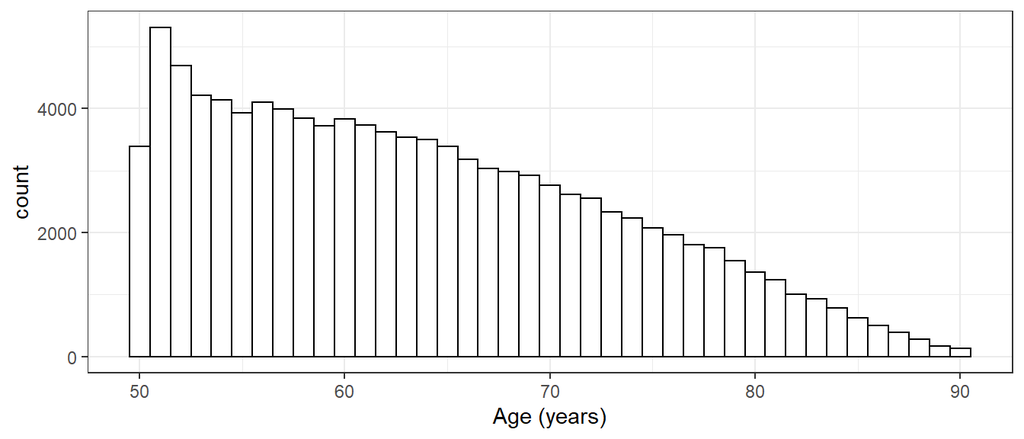

```r
ggplot(share.data.first.interview.model, aes(age_int)) + geom_histogram(binwidth = 1, color="black", fill="white") + labs(x="Age (years)") + theme_bw()
```

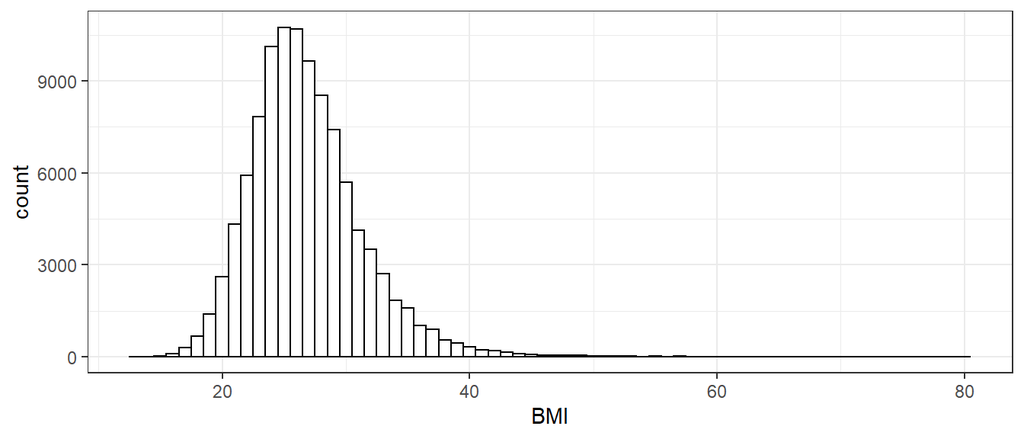

```r
ggplot(share.data.first.interview.model, aes(bmi_imp)) + geom_histogram(binwidth = 1, color="black", fill="white") + labs(x="BMI") + theme_bw()
```

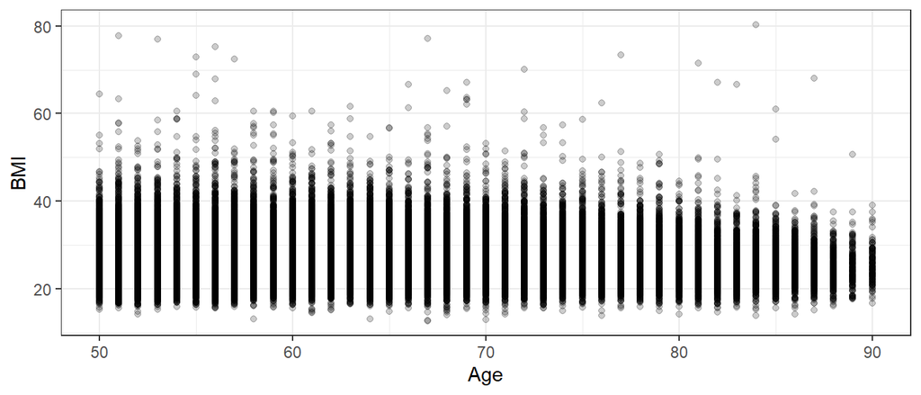

```r
ggplot(share.data.first.interview.model, aes(age_int, bmi_imp)) + geom_point(alpha=.2) + labs(y="BMI", x="Age") + theme_bw()
```

Age was positively asymmetrically distributed; the number of participants in each age year steadily decreased, with the exception of age 50, where the number of participants was lower than expected. The distribution of BMI was slightly positively asymmetric. The variability of BMI decreased with age.

#### 2.2.1.2 Categorical variables (nominal)

We now provide a closer visual examination of the categorical predictors.

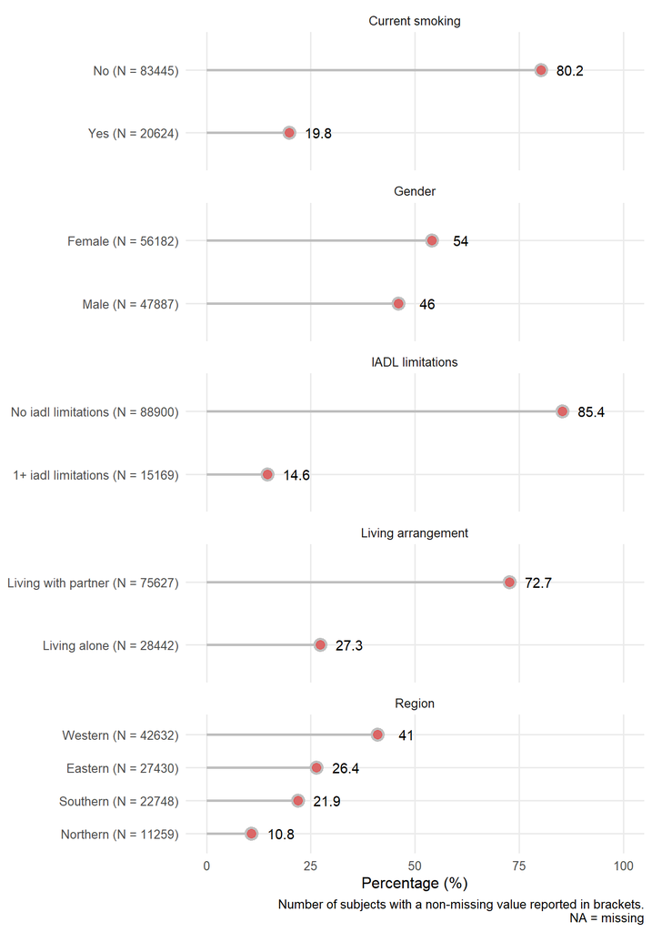

```r
share.data.first.interview.model %>%
  dplyr::select(gender, region, cusmoke_imp, iadl2, living_arrangement) %>%
  dplyr::mutate_all(forcats::as_factor) %>%
  dplyr::mutate_all(forcats::fct_explicit_na, "NA") %>%
  tidyr::pivot_longer(
    dplyr::everything(),
    names_to = "var",
    values_to = "value",
    values_drop_na = FALSE
  ) %>%
  dplyr::group_by(var, value) %>%
  dplyr::summarize(N = n()) %>%
  dplyr::mutate(
    freq = N / sum(N),
    pct = round((freq * 100), 1),
    axis_lab = paste0(value, ' ', '(N = ', N, ')'),
    var_label = case_when(var == "gender" ~ "Gender",
                          var == "cusmoke_imp" ~ "Current smoking",
                          var == "iadl2" ~ "IADL limitations",
                          var == "living_arrangement" ~ "Living arrangement",
                          var == "region" ~ "Region"
                          )
  ) %>%
  ggplot(aes(
    x = reorder(axis_lab, pct),
    y = pct,
    label = pct
  )) +
  geom_text(nudge_y = 7) +
  geom_pointrange(aes(ymin = 0, ymax = pct), alpha = 1, size = 1, color = "grey") +
  geom_point(color = "firebrick2",
             alpha = 0.6,
             size = 3) +
  ylab("Percentage (%)") +
  scale_y_continuous(limits = c(0, 100)) +
  labs(caption = "Number of subjects with a non-missing value reported in brackets.\nNA = missing") +
  facet_wrap(~ var_label, ncol = 1, scales = "free_y") +
  coord_flip() +
  theme_minimal(base_size = 12) +
  theme(axis.title.y = element_blank(),
        panel.grid.minor = element_blank())
```

#### 2.2.1.3 Categorical variables (ordinal)

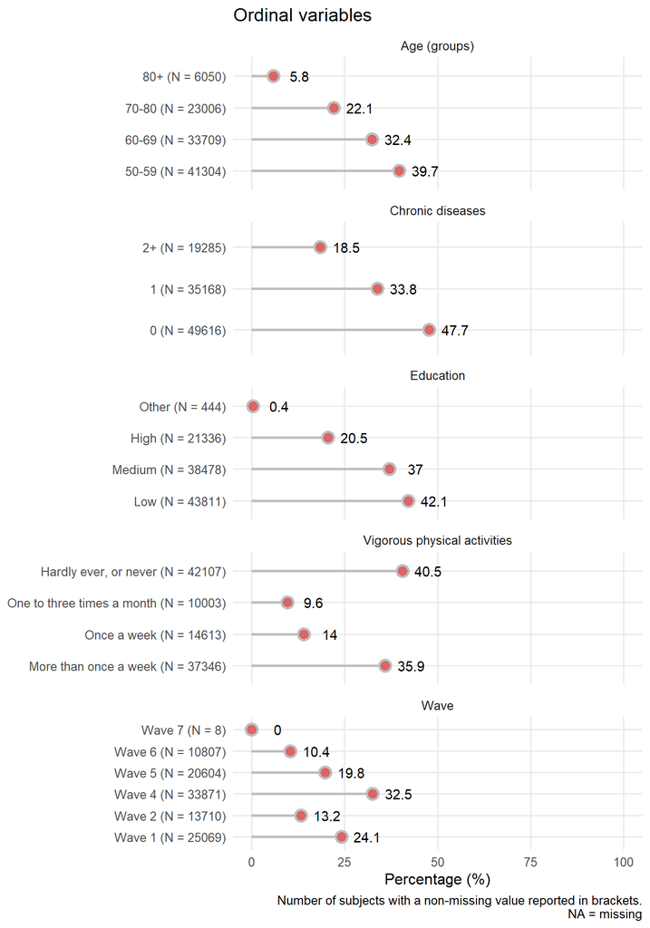

```r
share.data.first.interview.model %>%
  dplyr::select(age_int_cat, Wave, education_imp, pa_vig, dis_chronic_pres )  %>%
  #dplyr::mutate(gcs = as_factor(gcs)) %>%
  tidyr::pivot_longer(
    dplyr::everything(),
    names_to = "var",
    values_to = "value",
    values_drop_na = FALSE
  ) %>%
  dplyr::group_by(var, value) %>%
  dplyr::summarize(N = n()) %>%
  dplyr::mutate(
    freq = N / sum(N),
    pct = round((freq * 100), 1),
    value = as_factor(value),
    axis_lab = as_factor(paste0(value, ' ', '(N = ', N, ')')),
     var_label = case_when(var == "age_int_cat" ~ "Age (groups)",
                          var == "Wave" ~ "Wave",
                          var == "education_imp" ~ "Education",
                          var == "pa_vig" ~ "Vigorous physical activities",
                          var == "dis_chronic_pres" ~ "Chronic diseases"
                          )
  ) %>%
  ggplot(aes(
    x = axis_lab,
    y = pct,
    label = pct
  )) +
  geom_text(nudge_y = 7) +
  geom_pointrange(aes(ymin = 0, ymax = pct), alpha = 1, size = 1, color = "grey") +
  geom_point(color = "firebrick2",
             alpha = 0.6,
             size = 3) +
  ylab("Percentage (%)") +
  scale_y_continuous(limits = c(0, 100)) +
  labs(title = "Ordinal variables",
    caption = "Number of subjects with a non-missing value reported in brackets.\nNA = missing") +
  coord_flip() +
  theme_minimal(base_size = 12) +
  theme(axis.title.y = element_blank(),
        panel.grid.minor = element_blank())+
facet_wrap(~ var_label, ncol = 1, scales = "free_y")
```

#### 2.2.1.4 Outcome variable

#### 2.2.1.5 EURO-D score

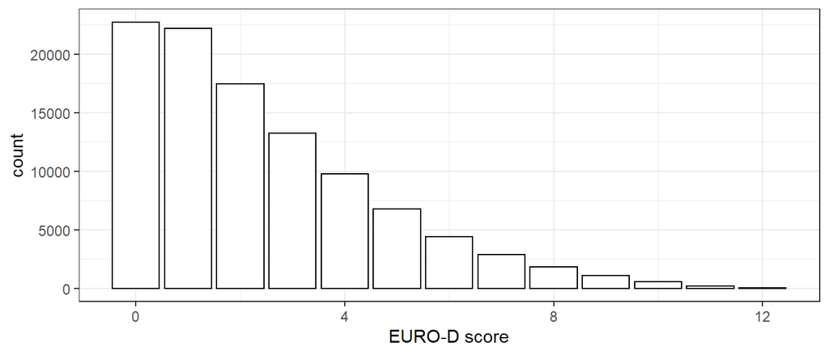

```r
ggplot(share.data.first.interview.model, aes(eurod)) + geom_bar(color="black", fill="white") + labs(x="EURO-D score") + theme_bw()
```

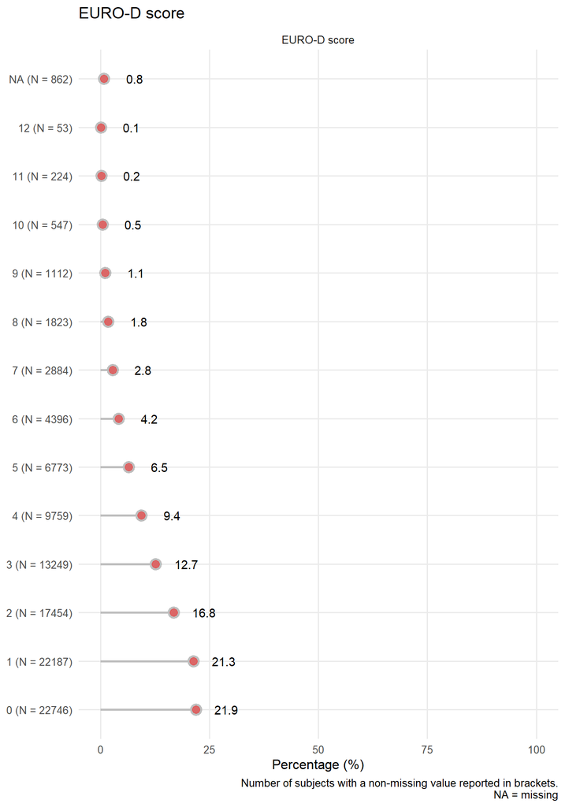

```r
share.data.first.interview.model %>%
  dplyr::select(eurod)  %>%
  #dplyr::mutate(gcs = as_factor(gcs)) %>%
  tidyr::pivot_longer(
    dplyr::everything(),
    names_to = "var",
    values_to = "value",
    values_drop_na = FALSE
  ) %>%
  dplyr::group_by(var, value) %>%
  dplyr::summarize(N = n()) %>%
  dplyr::mutate(
    freq = N / sum(N),
    pct = round((freq * 100), 1),
    value = as_factor(value),
    axis_lab = as_factor(paste0(value, ' ', '(N = ', N, ')')),
     var_label = case_when( var =="eurod" ~ "EURO-D score"
                          )
  ) %>%
  ggplot(aes(
    x = axis_lab,
    y = pct,
    label = pct
  )) +
  geom_text(nudge_y = 7) +
  geom_pointrange(aes(ymin = 0, ymax = pct), alpha = 1, size = 1, color = "grey") +
  geom_point(color = "firebrick2",
             alpha = 0.6,
             size = 3) +
  ylab("Percentage (%)") +
  scale_y_continuous(limits = c(0, 100)) +
  labs(title = "EURO-D score",
    caption = "Number of subjects with a non-missing value reported in brackets.\nNA = missing") +
  coord_flip() +
  theme_minimal(base_size = 12) +
  theme(axis.title.y = element_blank(),
        panel.grid.minor = element_blank())+
facet_wrap(~ var_label, ncol = 1, scales = "free_y")
```

#### 2.2.1.6 Binary outcome: EURO-D of 4 or greater

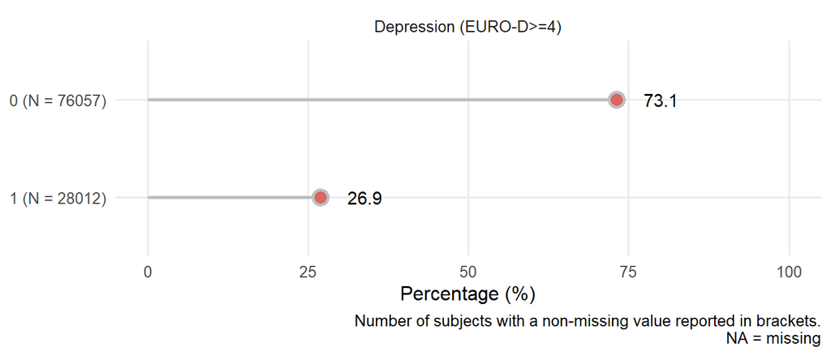

```r
share.data.first.interview.model %>%
  dplyr::select(eurodcat_imp_f) %>%
  dplyr::mutate_all(forcats::as_factor) %>%
  dplyr::mutate_all(forcats::fct_explicit_na, "NA") %>%
  tidyr::pivot_longer(
    dplyr::everything(),
    names_to = "var",
    values_to = "value",
    values_drop_na = FALSE
  ) %>%
  dplyr::group_by(var, value) %>%
  dplyr::summarize(N = n()) %>%
  dplyr::mutate(
    freq = N / sum(N),
    pct = round((freq * 100), 1),
    axis_lab = paste0(value, ' ', '(N = ', N, ')'),
    var_label = case_when(var == "eurodcat_imp_f" ~ "Depression (EURO-D>=4)"
                          )
  ) %>%
  ggplot(aes(
    x = reorder(axis_lab, pct),
    y = pct,
    label = pct
  )) +
  geom_text(nudge_y = 7) +
  geom_pointrange(aes(ymin = 0, ymax = pct), alpha = 1, size = 1, color = "grey") +
  geom_point(color = "firebrick2",
             alpha = 0.6,
             size = 3) +
  ylab("Percentage (%)") +
  scale_y_continuous(limits = c(0, 100)) +
  labs(caption = "Number of subjects with a non-missing value reported in brackets.\nNA = missing") +
  facet_wrap(~ var_label, ncol = 1, scales = "free_y") +
  coord_flip() +
  theme_minimal(base_size = 12) +
  theme(axis.title.y = element_blank(),
        panel.grid.minor = element_blank())
```

## 2.3 Multivariate analyses

The pivotal variables were gender, age, and region. Thus, this section is structured according to these variables. The distribution of explanatory variables in the statistical model can be stratified by these variables.

### 2.3.1 Descriptive statistics stratified by gender

```r
s <-
    Hmisc::summaryM(
        region + age_int+ age_int_cat+   education_imp +  bmi_imp + living_arrangement+  pa_vig +  cusmoke_imp +  dis_chronic_pres + iadl2 ~ gender ,
        data = share.data.first.interview.model,
        overall = FALSE,
        test = FALSE
    )

Hmisc::html(
    s,
    caption = 'Baseline characteristics by gender',
    exclude1 = TRUE,
    npct = 'both',
    digits = 3,
    prmsd = TRUE,
    brmsd = TRUE,
    msdsize = mu$smaller2
)
```

| Baseline characteristics by gender. | Baseline characteristics by gender. Male *N=47887* | Baseline characteristics by gender. Female *N=56182* |
| --- | --- | --- |
| region : Northern | 0.11 <sup>5385</sup>/<sub>47887</sub> | 0.10 <sup>5874</sup>/<sub>56182</sub> |
| Western | 0.41 <sup>19873</sup>/<sub>47887</sub> | 0.41 <sup>22759</sup>/<sub>56182</sub> |
| Southern | 0.22 <sup>10672</sup>/<sub>47887</sub> | 0.21 <sup>12076</sup>/<sub>56182</sub> |
| Eastern | 0.25 <sup>11957</sup>/<sub>47887</sub> | 0.28 <sup>15473</sup>/<sub>56182</sub> |
| age_int | 56.00 63.00 71.00 63.76 ± 9.39 | 55.00 62.00 71.00 63.63 ± 9.72 |
| age_int_cat : 50-59 | 0.39 <sup>18529</sup>/<sub>47887</sub> | 0.41 <sup>22775</sup>/<sub>56182</sub> |
| 60-69 | 0.34 <sup>16082</sup>/<sub>47887</sub> | 0.31 <sup>17627</sup>/<sub>56182</sub> |
| 70-80 | 0.22 <sup>10676</sup>/<sub>47887</sub> | 0.22 <sup>12330</sup>/<sub>56182</sub> |
| 80+ | 0.05 <sup>2600</sup>/<sub>47887</sub> | 0.06 <sup>3450</sup>/<sub>56182</sub> |
| education_imp : Low | 0.38 <sup>18000</sup>/<sub>47887</sub> | 0.46 <sup>25811</sup>/<sub>56182</sub> |
| Medium | 0.39 <sup>18693</sup>/<sub>47887</sub> | 0.35 <sup>19785</sup>/<sub>56182</sub> |
| High | 0.23 <sup>11004</sup>/<sub>47887</sub> | 0.18 <sup>10332</sup>/<sub>56182</sub> |
| Other | 0.00 <sup>190</sup>/<sub>47887</sub> | 0.00 <sup>254</sup>/<sub>56182</sub> |
| bmi_imp | 24.49 26.57 29.30 27.11 ± 4.05 | 23.15 25.85 29.30 26.57 ± 4.94 |
| living_arrangement : Living alone | 0.19 <sup>9253</sup>/<sub>47887</sub> | 0.34 <sup>19189</sup>/<sub>56182</sub> |
| pa_vig : More than once a week | 0.41 <sup>19449</sup>/<sub>47887</sub> | 0.32 <sup>17897</sup>/<sub>56182</sub> |
| Once a week | 0.14 <sup>6519</sup>/<sub>47887</sub> | 0.14 <sup>8094</sup>/<sub>56182</sub> |
| One to three times a month | 0.10 <sup>4664</sup>/<sub>47887</sub> | 0.10 <sup>5339</sup>/<sub>56182</sub> |
| Hardly ever, or never | 0.36 <sup>17255</sup>/<sub>47887</sub> | 0.44 <sup>24852</sup>/<sub>56182</sub> |
| cusmoke_imp : Yes | 0.24 <sup>11313</sup>/<sub>47887</sub> | 0.17 <sup>9311</sup>/<sub>56182</sub> |
| dis_chronic_pres : 0 | 0.47 <sup>22270</sup>/<sub>47887</sub> | 0.49 <sup>27346</sup>/<sub>56182</sub> |
| 1 | 0.34 <sup>16250</sup>/<sub>47887</sub> | 0.34 <sup>18918</sup>/<sub>56182</sub> |
| 2+ | 0.20 <sup>9367</sup>/<sub>47887</sub> | 0.18 <sup>9918</sup>/<sub>56182</sub> |
| iadl2 : 1+ iadl limitations | 0.11 <sup>5117</sup>/<sub>47887</sub> | 0.18 <sup>10052</sup>/<sub>56182</sub> |

*a* *b* *c* represent the lower quartile *a*, the median *b*, and the upper quartile *c* for continuous variables. *x ± s* represents X ± 1 SD.

```r
mylatex <- function (...) {
    o <- capture.output(latex(file = "", where = "!htbp", ...))
    # this will strip /all/ line-only comments; or if you're only
    #  interested in stripping the first such comment you could
    #  adjust accordingly
    o <- grep('^%', o, inv=T, value=T)
    cat(o, sep='\n')
}



#saving the table for the paper
tex.table <- latex(
    s, digits=2, what="%", file="out/Table1Gender.tex")
```

Males and females had similar distributions in all regions (slightly more women in Eastern region), similar age (women were slightly younger) and number of chronic diseases. Women had lower education, had vigorous physical activity less often and smoked less often, they lived alone more often and had more iadl limitations.

#### 2.3.1.1 Graphical presentation of age and BMI by gender

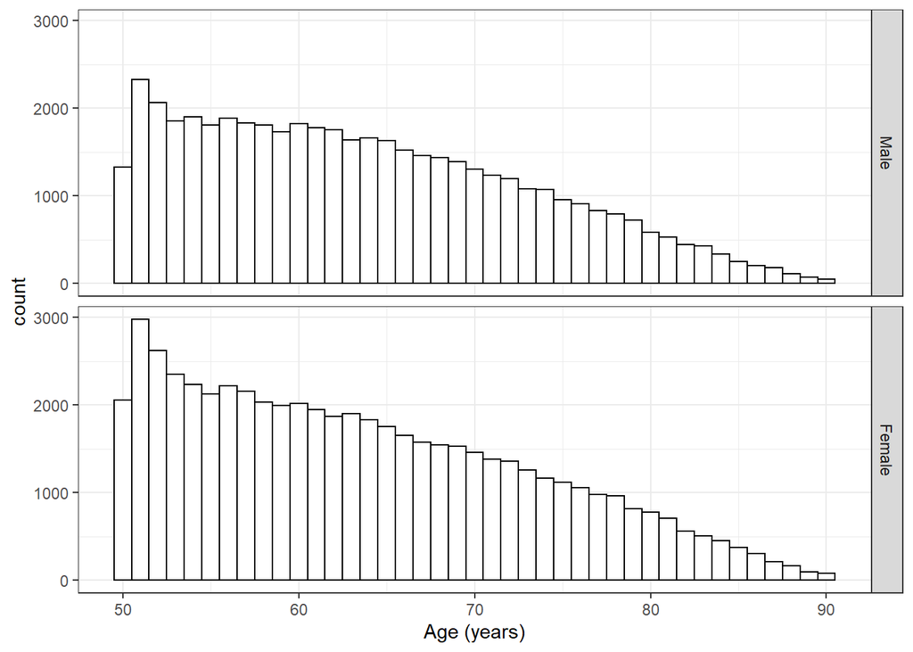

```r
ggplot(share.data.first.interview.model, aes(age_int)) + geom_histogram(binwidth = 1, color="black", fill="white") + labs(x="Age (years)") + theme_bw() + facet_grid(gender~.)
```

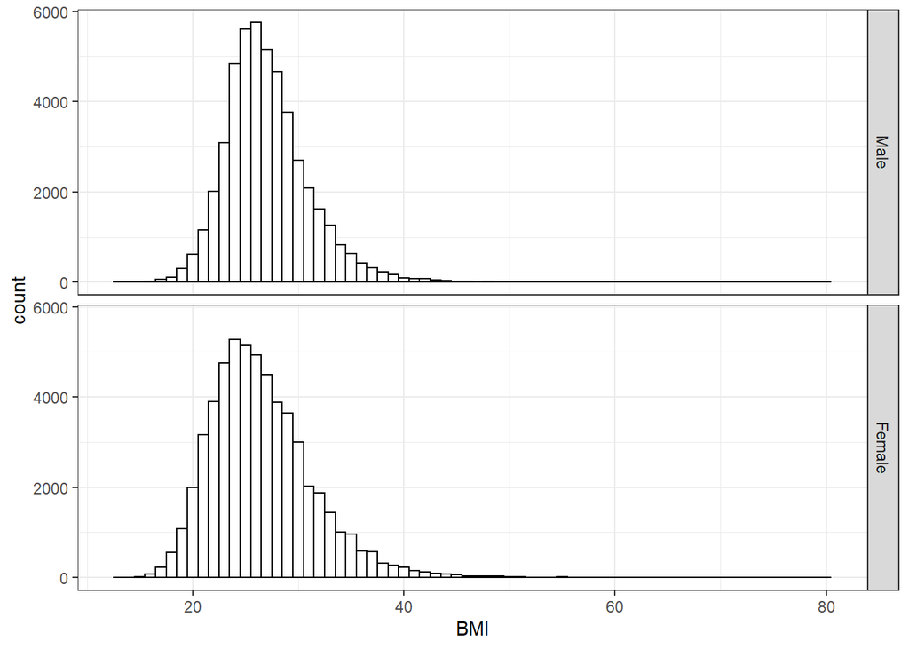

```r
ggplot(share.data.first.interview.model, aes(bmi_imp)) + geom_histogram(binwidth = 1, color="black", fill="white") + labs(x="BMI") + theme_bw()+ facet_grid(gender~.)
```

Age was positively asymmetrically distributed; the number of participants in each age year steadily decreased, with the exception of age 50, where the number of participants was lower than expected. The distribution of BMI was slightly positively asymmetric.

### 2.3.2 Descriptive statistics stratified by gender and region

Participants were categorized by gender and region, and compared by their first interview characteristics.

```r
s <-
    Hmisc::summaryM(
        age_int+ age_int_cat+   education_imp +  bmi_imp + living_arrangement+  pa_vig +  cusmoke_imp +  dis_chronic_pres + iadl2 + eurodcat_imp_f~ gender + region ,
        data = share.data.first.interview.model,
        overall = FALSE,
        test = FALSE
    )

Hmisc::html(
    s,
    caption = 'Baseline characteristics by gender and region',
    exclude1 = TRUE,
    npct = 'both',
    digits = 3,
    prmsd = TRUE,
    brmsd = TRUE,
    msdsize = mu$smaller2
)
```

| Baseline characteristics by gender and region. | Baseline characteristics by gender and region. Male *N=11957* | Baseline characteristics by gender and region. Female *N=15473* |
| --- | --- | --- |
| Northern |  |  |
| age_int | 56.00 63.00 71.00 63.82 ± 9.56 | 55.00 62.00 70.00 63.17 ± 9.51 |
| age_int_cat : 50-59 | 0.38 <sup>2056</sup>/<sub>5385</sub> | 0.42 <sup>2438</sup>/<sub>5874</sub> |
| 60-69 | 0.34 <sup>1825</sup>/<sub>5385</sub> | 0.33 <sup>1925</sup>/<sub>5874</sub> |
| 70-80 | 0.22 <sup>1187</sup>/<sub>5385</sub> | 0.20 <sup>1199</sup>/<sub>5874</sub> |
| 80+ | 0.06 <sup>317</sup>/<sub>5385</sub> | 0.05 <sup>312</sup>/<sub>5874</sub> |
| education_imp : Low | 0.30 <sup>1641</sup>/<sub>5385</sub> | 0.33 <sup>1956</sup>/<sub>5874</sub> |
| Medium | 0.38 <sup>2059</sup>/<sub>5385</sub> | 0.31 <sup>1836</sup>/<sub>5874</sub> |
| High | 0.31 <sup>1651</sup>/<sub>5385</sub> | 0.35 <sup>2042</sup>/<sub>5874</sub> |
| Other | 0.01 <sup>34</sup>/<sub>5385</sub> | 0.01 <sup>40</sup>/<sub>5874</sub> |
| bmi_imp | 23.96 25.93 28.40 26.38 ± 3.68 | 22.51 24.84 27.97 25.52 ± 4.32 |
| living_arrangement : Living alone | 0.21 <sup>1114</sup>/<sub>5385</sub> | 0.30 <sup>1764</sup>/<sub>5874</sub> |
| pa_vig : More than once a week | 0.50 <sup>2716</sup>/<sub>5385</sub> | 0.41 <sup>2432</sup>/<sub>5874</sub> |
| Once a week | 0.14 <sup>732</sup>/<sub>5385</sub> | 0.15 <sup>874</sup>/<sub>5874</sub> |
| One to three times a month | 0.09 <sup>461</sup>/<sub>5385</sub> | 0.08 <sup>448</sup>/<sub>5874</sub> |
| Hardly ever, or never | 0.27 <sup>1476</sup>/<sub>5385</sub> | 0.36 <sup>2120</sup>/<sub>5874</sub> |
| cusmoke_imp : Yes | 0.20 <sup>1055</sup>/<sub>5385</sub> | 0.21 <sup>1213</sup>/<sub>5874</sub> |
| dis_chronic_pres : 0 | 0.49 <sup>2620</sup>/<sub>5385</sub> | 0.52 <sup>3071</sup>/<sub>5874</sub> |
| 1 | 0.33 <sup>1758</sup>/<sub>5385</sub> | 0.33 <sup>1917</sup>/<sub>5874</sub> |
| 2+ | 0.19 <sup>1007</sup>/<sub>5385</sub> | 0.15 <sup>886</sup>/<sub>5874</sub> |
| iadl2 : 1+ iadl limitations | 0.08 <sup>446</sup>/<sub>5385</sub> | 0.14 <sup>806</sup>/<sub>5874</sub> |
| eurodcat_imp_f | 0.12 <sup>646</sup>/<sub>5385</sub> | 0.23 <sup>1347</sup>/<sub>5874</sub> |
| Western |  |  |
| age_int | 55.00 62.00 70.00 63.20 ± 9.43 | 55.00 62.00 70.00 63.16 ± 9.79 |
| age_int_cat : 50-59 | 0.41 <sup>8231</sup>/<sub>19873</sub> | 0.43 <sup>9782</sup>/<sub>22759</sub> |
| 60-69 | 0.33 <sup>6466</sup>/<sub>19873</sub> | 0.30 <sup>6866</sup>/<sub>22759</sub> |
| 70-80 | 0.21 <sup>4173</sup>/<sub>19873</sub> | 0.21 <sup>4712</sup>/<sub>22759</sub> |
| 80+ | 0.05 <sup>1003</sup>/<sub>19873</sub> | 0.06 <sup>1399</sup>/<sub>22759</sub> |
| education_imp : Low | 0.28 <sup>5655</sup>/<sub>19873</sub> | 0.40 <sup>9082</sup>/<sub>22759</sub> |
| Medium | 0.42 <sup>8317</sup>/<sub>19873</sub> | 0.38 <sup>8732</sup>/<sub>22759</sub> |

[output cut: 58 more lines]

*a* *b* *c* represent the lower quartile *a*, the median *b*, and the upper quartile *c* for continuous variables. *x ± s* represents X ± 1 SD.

```r
#TEX TO EDIT THE TABLE FOR THE PAPER
tex.table <- latex(
    s, digits=2, what="%", file="out/Table1RegionsGender.tex")
```

The age distribution was similar across regions and genders. Overall, females had lower education, lived alone more often, had less physical activity, smoked less often, had slightly less chronic diseases but more iadl limitations, depression was more common. The differences between genders were less pronounced in the Northern region. Regions differed in some aspects: education was substantially lower in Southern region, where living alone and vigorous activity were less common. Comorbidities and iadl limitations were more common in Easter region, vigorous physical activity and higher education in Northern region.

#### 2.3.2.1 Graphical presentation of age and BMI by gender and region

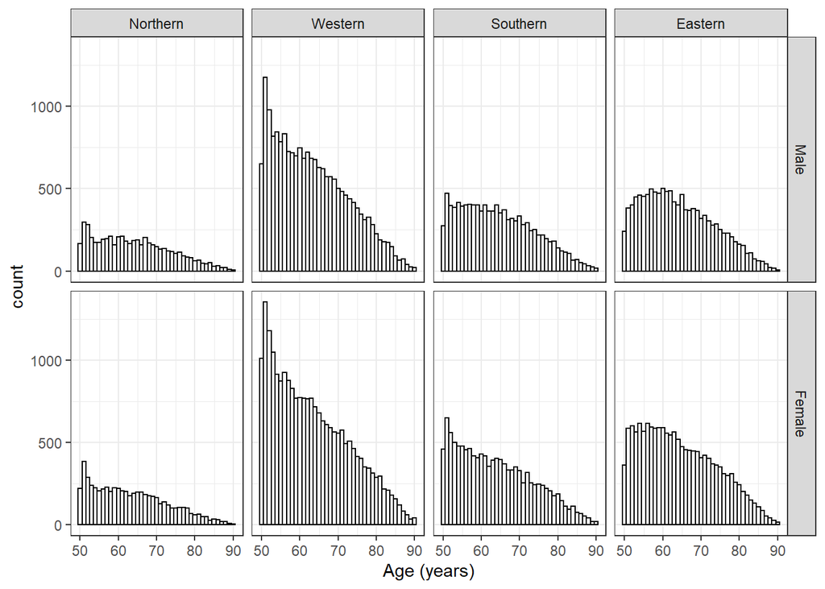

```r
ggplot(share.data.first.interview.model, aes(age_int)) + geom_histogram(binwidth = 1, color="black", fill="white") + labs(x="Age (years)") + theme_bw() + facet_grid(gender~region)
```

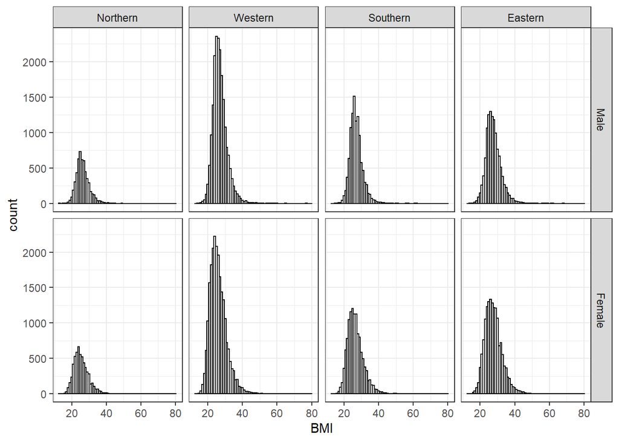

```r
ggplot(share.data.first.interview.model, aes(bmi_imp)) + geom_histogram(binwidth = 1, color="black", fill="white") + labs(x="BMI") + theme_bw()+ facet_grid(gender~region)
```

### 2.3.3 First interview measurements stratified by age

```r
s <-
  Hmisc::summaryM(
  region+ gender +   education_imp +  bmi_imp + living_arrangement+  pa_vig +  cusmoke_imp +  dis_chronic_pres + iadl2 +  eurodcat_imp_f ~ age_int_cat,
    data = share.data.first.interview.model,
    overall = FALSE,
    test = FALSE
  )

Hmisc::html(
  s,
  caption = 'Baseline characteristics by age category for females',
  exclude1 = TRUE,
  npct = 'both',
  digits = 3,
  prmsd = TRUE,
  brmsd = TRUE,
  msdsize = mu$smaller2
)
```

| Baseline characteristics by age category for females. | Baseline characteristics by age category for females. 50-59 *N=41304* | Baseline characteristics by age category for females. 60-69 *N=33709* | Baseline characteristics by age category for females. 70-80 *N=23006* | Baseline characteristics by age category for females. 80+ *N=6050* |
| --- | --- | --- | --- | --- |
| region : Northern | 0.11 <sup>4494</sup>/<sub>41304</sub> | 0.11 <sup>3750</sup>/<sub>33709</sub> | 0.10 <sup>2386</sup>/<sub>23006</sub> | 0.10 <sup>629</sup>/<sub>6050</sub> |
| Western | 0.44 <sup>18013</sup>/<sub>41304</sub> | 0.40 <sup>13332</sup>/<sub>33709</sub> | 0.39 <sup>8885</sup>/<sub>23006</sub> | 0.40 <sup>2402</sup>/<sub>6050</sub> |
| Southern | 0.21 <sup>8817</sup>/<sub>41304</sub> | 0.22 <sup>7335</sup>/<sub>33709</sub> | 0.23 <sup>5218</sup>/<sub>23006</sub> | 0.23 <sup>1378</sup>/<sub>6050</sub> |
| Eastern | 0.24 <sup>9980</sup>/<sub>41304</sub> | 0.28 <sup>9292</sup>/<sub>33709</sub> | 0.28 <sup>6517</sup>/<sub>23006</sub> | 0.27 <sup>1641</sup>/<sub>6050</sub> |
| gender : Female | 0.55 <sup>22775</sup>/<sub>41304</sub> | 0.52 <sup>17627</sup>/<sub>33709</sub> | 0.54 <sup>12330</sup>/<sub>23006</sub> | 0.57 <sup>3450</sup>/<sub>6050</sub> |
| education_imp : Low | 0.32 <sup>13115</sup>/<sub>41304</sub> | 0.42 <sup>14103</sup>/<sub>33709</sub> | 0.55 <sup>12707</sup>/<sub>23006</sub> | 0.64 <sup>3886</sup>/<sub>6050</sub> |
| Medium | 0.43 <sup>17722</sup>/<sub>41304</sub> | 0.38 <sup>12682</sup>/<sub>33709</sub> | 0.29 <sup>6677</sup>/<sub>23006</sub> | 0.23 <sup>1397</sup>/<sub>6050</sub> |
| High | 0.25 <sup>10298</sup>/<sub>41304</sub> | 0.20 <sup>6788</sup>/<sub>33709</sub> | 0.15 <sup>3511</sup>/<sub>23006</sub> | 0.12 <sup>739</sup>/<sub>6050</sub> |
| Other | 0.00 <sup>169</sup>/<sub>41304</sub> | 0.00 <sup>136</sup>/<sub>33709</sub> | 0.00 <sup>111</sup>/<sub>23006</sub> | 0.00 <sup>28</sup>/<sub>6050</sub> |
| bmi_imp | 23.51 25.96 29.07 26.64 ± 4.68 | 24.16 26.57 29.45 27.16 ± 4.55 | 24.03 26.40 29.35 26.90 ± 4.36 | 23.14 25.39 28.23 25.85 ± 4.34 |
| living_arrangement : Living alone | 0.24 <sup>9791</sup>/<sub>41304</sub> | 0.23 <sup>7912</sup>/<sub>33709</sub> | 0.33 <sup>7587</sup>/<sub>23006</sub> | 0.52 <sup>3152</sup>/<sub>6050</sub> |
| pa_vig : More than once a week | 0.46 <sup>18803</sup>/<sub>41304</sub> | 0.36 <sup>12131</sup>/<sub>33709</sub> | 0.25 <sup>5640</sup>/<sub>23006</sub> | 0.13 <sup>772</sup>/<sub>6050</sub> |
| Once a week | 0.15 <sup>6294</sup>/<sub>41304</sub> | 0.15 <sup>5190</sup>/<sub>33709</sub> | 0.12 <sup>2706</sup>/<sub>23006</sub> | 0.07 <sup>423</sup>/<sub>6050</sub> |
| One to three times a month | 0.10 <sup>3952</sup>/<sub>41304</sub> | 0.10 <sup>3466</sup>/<sub>33709</sub> | 0.10 <sup>2212</sup>/<sub>23006</sub> | 0.06 <sup>373</sup>/<sub>6050</sub> |
| Hardly ever, or never | 0.30 <sup>12255</sup>/<sub>41304</sub> | 0.38 <sup>12922</sup>/<sub>33709</sub> | 0.54 <sup>12448</sup>/<sub>23006</sub> | 0.74 <sup>4482</sup>/<sub>6050</sub> |
| cusmoke_imp : Yes | 0.29 <sup>11796</sup>/<sub>41304</sub> | 0.19 <sup>6310</sup>/<sub>33709</sub> | 0.10 <sup>2207</sup>/<sub>23006</sub> | 0.05 <sup>311</sup>/<sub>6050</sub> |
| dis_chronic_pres : 0 | 0.62 <sup>25806</sup>/<sub>41304</sub> | 0.44 <sup>14952</sup>/<sub>33709</sub> | 0.31 <sup>7218</sup>/<sub>23006</sub> | 0.27 <sup>1640</sup>/<sub>6050</sub> |
| 1 | 0.28 <sup>11567</sup>/<sub>41304</sub> | 0.37 <sup>12306</sup>/<sub>33709</sub> | 0.39 <sup>8892</sup>/<sub>23006</sub> | 0.40 <sup>2403</sup>/<sub>6050</sub> |
| 2+ | 0.10 <sup>3931</sup>/<sub>41304</sub> | 0.19 <sup>6451</sup>/<sub>33709</sub> | 0.30 <sup>6896</sup>/<sub>23006</sub> | 0.33 <sup>2007</sup>/<sub>6050</sub> |
| iadl2 : 1+ iadl limitations | 0.08 <sup>3368</sup>/<sub>41304</sub> | 0.11 <sup>3848</sup>/<sub>33709</sub> | 0.23 <sup>5260</sup>/<sub>23006</sub> | 0.45 <sup>2693</sup>/<sub>6050</sub> |
| eurodcat_imp_f | 0.25 <sup>10507</sup>/<sub>41304</sub> | 0.24 <sup>8091</sup>/<sub>33709</sub> | 0.30 <sup>6970</sup>/<sub>23006</sub> | 0.40 <sup>2444</sup>/<sub>6050</sub> |

*a* *b* *c* represent the lower quartile *a*, the median *b*, and the upper quartile *c* for continuous variables. *x ± s* represents X ± 1 SD.

#### 2.3.3.1 Graphical presentation of BMI stratified by age category and gender

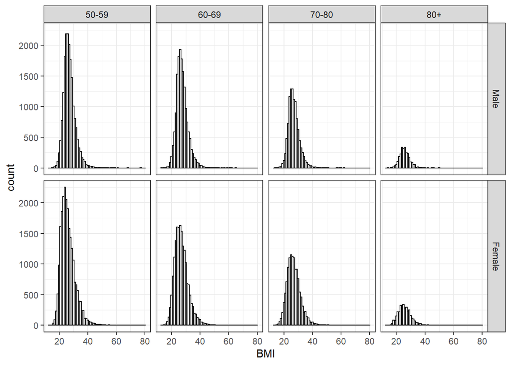

```r
ggplot(share.data.first.interview.model, aes(bmi_imp)) + geom_histogram(binwidth = 1, color="black", fill="white") + labs(x="BMI") + theme_bw()+ facet_grid(gender~age_int_cat)
```

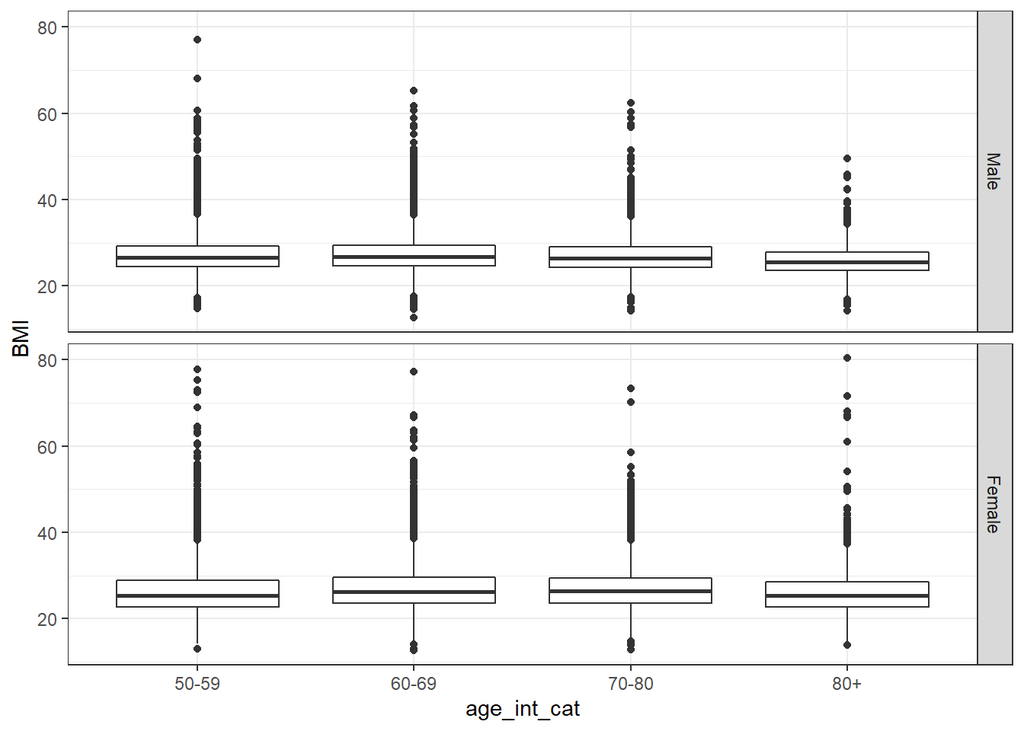

```r
ggplot(share.data.first.interview.model, aes(age_int_cat, bmi_imp)) + geom_boxplot() + labs(y="BMI") + theme_bw() + facet_grid(gender~.)
```

### 2.3.4 Baseline measurements stratified by age and gender

#### 2.3.4.1 Females

```r
s <-
  Hmisc::summaryM(
   region + education_imp +  bmi_imp + living_arrangement+  pa_vig +  cusmoke_imp +  dis_chronic_pres + iadl2 + eurodcat_imp_f ~ age_int_cat,
    data = droplevels(subset(share.data.first.interview.model, gender=="Female")),
    overall = FALSE,
    test = FALSE
  )


Hmisc::html(
  s,
  caption = 'Baseline characteristics by age category for females',
  exclude1 = TRUE,
  npct = 'both',
  digits = 3,
  prmsd = TRUE,
  brmsd = TRUE,
  msdsize = mu$smaller2
)
```

| Baseline characteristics by age category for females. | Baseline characteristics by age category for females. 50-59 *N=22775* | Baseline characteristics by age category for females. 60-69 *N=17627* | Baseline characteristics by age category for females. 70-80 *N=12330* | Baseline characteristics by age category for females. 80+ *N=3450* |
| --- | --- | --- | --- | --- |
| region : Northern | 0.11 <sup>2438</sup>/<sub>22775</sub> | 0.11 <sup>1925</sup>/<sub>17627</sub> | 0.10 <sup>1199</sup>/<sub>12330</sub> | 0.09 <sup>312</sup>/<sub>3450</sub> |
| Western | 0.43 <sup>9782</sup>/<sub>22775</sub> | 0.39 <sup>6866</sup>/<sub>17627</sub> | 0.38 <sup>4712</sup>/<sub>12330</sub> | 0.41 <sup>1399</sup>/<sub>3450</sub> |
| Southern | 0.21 <sup>4870</sup>/<sub>22775</sub> | 0.21 <sup>3784</sup>/<sub>17627</sub> | 0.22 <sup>2681</sup>/<sub>12330</sub> | 0.21 <sup>741</sup>/<sub>3450</sub> |
| Eastern | 0.25 <sup>5685</sup>/<sub>22775</sub> | 0.29 <sup>5052</sup>/<sub>17627</sub> | 0.30 <sup>3738</sup>/<sub>12330</sub> | 0.29 <sup>998</sup>/<sub>3450</sub> |
| education_imp : Low | 0.34 <sup>7662</sup>/<sub>22775</sub> | 0.46 <sup>8068</sup>/<sub>17627</sub> | 0.62 <sup>7624</sup>/<sub>12330</sub> | 0.71 <sup>2457</sup>/<sub>3450</sub> |
| Medium | 0.42 <sup>9486</sup>/<sub>22775</sub> | 0.36 <sup>6403</sup>/<sub>17627</sub> | 0.26 <sup>3183</sup>/<sub>12330</sub> | 0.21 <sup>713</sup>/<sub>3450</sub> |
| High | 0.24 <sup>5538</sup>/<sub>22775</sub> | 0.17 <sup>3072</sup>/<sub>17627</sub> | 0.12 <sup>1461</sup>/<sub>12330</sub> | 0.08 <sup>261</sup>/<sub>3450</sub> |
| Other | 0.00 <sup>89</sup>/<sub>22775</sub> | 0.00 <sup>84</sup>/<sub>17627</sub> | 0.01 <sup>62</sup>/<sub>12330</sub> | 0.01 <sup>19</sup>/<sub>3450</sub> |
| bmi_imp | 22.68 25.33 28.88 26.21 ± 5.04 | 23.56 26.29 29.59 26.95 ± 4.92 | 23.62 26.35 29.48 26.87 ± 4.76 | 22.77 25.39 28.58 25.88 ± 4.86 |
| living_arrangement : Living alone | 0.25 <sup>5806</sup>/<sub>22775</sub> | 0.30 <sup>5230</sup>/<sub>17627</sub> | 0.46 <sup>5694</sup>/<sub>12330</sub> | 0.71 <sup>2459</sup>/<sub>3450</sub> |
| pa_vig : More than once a week | 0.41 <sup>9444</sup>/<sub>22775</sub> | 0.32 <sup>5624</sup>/<sub>17627</sub> | 0.20 <sup>2522</sup>/<sub>12330</sub> | 0.09 <sup>307</sup>/<sub>3450</sub> |
| Once a week | 0.16 <sup>3614</sup>/<sub>22775</sub> | 0.16 <sup>2814</sup>/<sub>17627</sub> | 0.12 <sup>1442</sup>/<sub>12330</sub> | 0.06 <sup>224</sup>/<sub>3450</sub> |
| One to three times a month | 0.10 <sup>2228</sup>/<sub>22775</sub> | 0.10 <sup>1823</sup>/<sub>17627</sub> | 0.09 <sup>1099</sup>/<sub>12330</sub> | 0.05 <sup>189</sup>/<sub>3450</sub> |
| Hardly ever, or never | 0.33 <sup>7489</sup>/<sub>22775</sub> | 0.42 <sup>7366</sup>/<sub>17627</sub> | 0.59 <sup>7267</sup>/<sub>12330</sub> | 0.79 <sup>2730</sup>/<sub>3450</sub> |
| cusmoke_imp : Yes | 0.25 <sup>5731</sup>/<sub>22775</sub> | 0.15 <sup>2623</sup>/<sub>17627</sub> | 0.07 <sup>851</sup>/<sub>12330</sub> | 0.03 <sup>106</sup>/<sub>3450</sub> |
| dis_chronic_pres : 0 | 0.63 <sup>14399</sup>/<sub>22775</sub> | 0.46 <sup>8055</sup>/<sub>17627</sub> | 0.32 <sup>3941</sup>/<sub>12330</sub> | 0.28 <sup>951</sup>/<sub>3450</sub> |
| 1 | 0.28 <sup>6297</sup>/<sub>22775</sub> | 0.36 <sup>6430</sup>/<sub>17627</sub> | 0.39 <sup>4812</sup>/<sub>12330</sub> | 0.40 <sup>1379</sup>/<sub>3450</sub> |
| 2+ | 0.09 <sup>2079</sup>/<sub>22775</sub> | 0.18 <sup>3142</sup>/<sub>17627</sub> | 0.29 <sup>3577</sup>/<sub>12330</sub> | 0.32 <sup>1120</sup>/<sub>3450</sub> |
| iadl2 : 1+ iadl limitations | 0.10 <sup>2316</sup>/<sub>22775</sub> | 0.14 <sup>2503</sup>/<sub>17627</sub> | 0.28 <sup>3449</sup>/<sub>12330</sub> | 0.52 <sup>1784</sup>/<sub>3450</sub> |
| eurodcat_imp_f | 0.31 <sup>7158</sup>/<sub>22775</sub> | 0.31 <sup>5384</sup>/<sub>17627</sub> | 0.38 <sup>4651</sup>/<sub>12330</sub> | 0.48 <sup>1652</sup>/<sub>3450</sub> |

*a* *b* *c* represent the lower quartile *a*, the median *b*, and the upper quartile *c* for continuous variables. *x ± s* represents X ± 1 SD.

#### 2.3.4.2 Males

```r
s <-
  Hmisc::summaryM(
  region + education_imp +  bmi_imp + living_arrangement+  pa_vig +  cusmoke_imp +  dis_chronic_pres + iadl2 +  eurodcat_imp_f ~ age_int_cat,
   data = droplevels(subset(share.data.first.interview.model, gender=="Male")),
    overall = FALSE,
    test = FALSE
  )

Hmisc::html(
  s,
  caption = 'Baseline characteristics by age category for males',
  exclude1 = TRUE,
  npct = 'both',
  digits = 3,
  prmsd = TRUE,
  brmsd = TRUE,
  msdsize = mu$smaller2
)
```

| Baseline characteristics by age category for males. | Baseline characteristics by age category for males. 50-59 *N=18529* | Baseline characteristics by age category for males. 60-69 *N=16082* | Baseline characteristics by age category for males. 70-80 *N=10676* | Baseline characteristics by age category for males. 80+ *N=2600* |
| --- | --- | --- | --- | --- |
| region : Northern | 0.11 <sup>2056</sup>/<sub>18529</sub> | 0.11 <sup>1825</sup>/<sub>16082</sub> | 0.11 <sup>1187</sup>/<sub>10676</sub> | 0.12 <sup>317</sup>/<sub>2600</sub> |
| Western | 0.44 <sup>8231</sup>/<sub>18529</sub> | 0.40 <sup>6466</sup>/<sub>16082</sub> | 0.39 <sup>4173</sup>/<sub>10676</sub> | 0.39 <sup>1003</sup>/<sub>2600</sub> |
| Southern | 0.21 <sup>3947</sup>/<sub>18529</sub> | 0.22 <sup>3551</sup>/<sub>16082</sub> | 0.24 <sup>2537</sup>/<sub>10676</sub> | 0.24 <sup>637</sup>/<sub>2600</sub> |
| Eastern | 0.23 <sup>4295</sup>/<sub>18529</sub> | 0.26 <sup>4240</sup>/<sub>16082</sub> | 0.26 <sup>2779</sup>/<sub>10676</sub> | 0.25 <sup>643</sup>/<sub>2600</sub> |
| education_imp : Low | 0.29 <sup>5453</sup>/<sub>18529</sub> | 0.38 <sup>6035</sup>/<sub>16082</sub> | 0.48 <sup>5083</sup>/<sub>10676</sub> | 0.55 <sup>1429</sup>/<sub>2600</sub> |
| Medium | 0.44 <sup>8236</sup>/<sub>18529</sub> | 0.39 <sup>6279</sup>/<sub>16082</sub> | 0.33 <sup>3494</sup>/<sub>10676</sub> | 0.26 <sup>684</sup>/<sub>2600</sub> |
| High | 0.26 <sup>4760</sup>/<sub>18529</sub> | 0.23 <sup>3716</sup>/<sub>16082</sub> | 0.19 <sup>2050</sup>/<sub>10676</sub> | 0.18 <sup>478</sup>/<sub>2600</sub> |
| Other | 0.00 <sup>80</sup>/<sub>18529</sub> | 0.00 <sup>52</sup>/<sub>16082</sub> | 0.00 <sup>49</sup>/<sub>10676</sub> | 0.00 <sup>9</sup>/<sub>2600</sub> |
| bmi_imp | 24.49 26.57 29.32 27.16 ± 4.13 | 24.69 26.83 29.41 27.38 ± 4.11 | 24.38 26.42 29.05 26.93 ± 3.85 | 23.53 25.51 27.76 25.82 ± 3.53 |
| living_arrangement : Living alone | 0.22 <sup>3985</sup>/<sub>18529</sub> | 0.17 <sup>2682</sup>/<sub>16082</sub> | 0.18 <sup>1893</sup>/<sub>10676</sub> | 0.27 <sup>693</sup>/<sub>2600</sub> |
| pa_vig : More than once a week | 0.51 <sup>9359</sup>/<sub>18529</sub> | 0.40 <sup>6507</sup>/<sub>16082</sub> | 0.29 <sup>3118</sup>/<sub>10676</sub> | 0.18 <sup>465</sup>/<sub>2600</sub> |
| Once a week | 0.14 <sup>2680</sup>/<sub>18529</sub> | 0.15 <sup>2376</sup>/<sub>16082</sub> | 0.12 <sup>1264</sup>/<sub>10676</sub> | 0.08 <sup>199</sup>/<sub>2600</sub> |
| One to three times a month | 0.09 <sup>1724</sup>/<sub>18529</sub> | 0.10 <sup>1643</sup>/<sub>16082</sub> | 0.10 <sup>1113</sup>/<sub>10676</sub> | 0.07 <sup>184</sup>/<sub>2600</sub> |
| Hardly ever, or never | 0.26 <sup>4766</sup>/<sub>18529</sub> | 0.35 <sup>5556</sup>/<sub>16082</sub> | 0.49 <sup>5181</sup>/<sub>10676</sub> | 0.67 <sup>1752</sup>/<sub>2600</sub> |
| cusmoke_imp : Yes | 0.33 <sup>6065</sup>/<sub>18529</sub> | 0.23 <sup>3687</sup>/<sub>16082</sub> | 0.13 <sup>1356</sup>/<sub>10676</sub> | 0.08 <sup>205</sup>/<sub>2600</sub> |
| dis_chronic_pres : 0 | 0.62 <sup>11407</sup>/<sub>18529</sub> | 0.43 <sup>6897</sup>/<sub>16082</sub> | 0.31 <sup>3277</sup>/<sub>10676</sub> | 0.26 <sup>689</sup>/<sub>2600</sub> |
| 1 | 0.28 <sup>5270</sup>/<sub>18529</sub> | 0.37 <sup>5876</sup>/<sub>16082</sub> | 0.38 <sup>4080</sup>/<sub>10676</sub> | 0.39 <sup>1024</sup>/<sub>2600</sub> |
| 2+ | 0.10 <sup>1852</sup>/<sub>18529</sub> | 0.21 <sup>3309</sup>/<sub>16082</sub> | 0.31 <sup>3319</sup>/<sub>10676</sub> | 0.34 <sup>887</sup>/<sub>2600</sub> |
| iadl2 : 1+ iadl limitations | 0.06 <sup>1052</sup>/<sub>18529</sub> | 0.08 <sup>1345</sup>/<sub>16082</sub> | 0.17 <sup>1811</sup>/<sub>10676</sub> | 0.35 <sup>909</sup>/<sub>2600</sub> |
| eurodcat_imp_f | 0.18 <sup>3349</sup>/<sub>18529</sub> | 0.17 <sup>2707</sup>/<sub>16082</sub> | 0.22 <sup>2319</sup>/<sub>10676</sub> | 0.30 <sup>792</sup>/<sub>2600</sub> |

*a* *b* *c* represent the lower quartile *a*, the median *b*, and the upper quartile *c* for continuous variables. *x ± s* represents X ± 1 SD.

### 2.3.5 Additional explorations

#### 2.3.5.1 Wave of first interview and region

```r
kable(table(share.data.first.interview$Wave, share.data.first.interview$region))
```

|  | Northern | Western | Southern | Eastern |
| --- | --- | --- | --- | --- |
| Wave 1 | 4375 | 14380 | 7113 | 0 |
| Wave 2 | 1936 | 4768 | 2829 | 4925 |
| Wave 4 | 543 | 13847 | 5077 | 16357 |
| Wave 5 | 4439 | 9433 | 4895 | 2556 |
| Wave 6 | 364 | 1977 | 4119 | 4985 |
| Wave 7 | 0 | 1 | 6 | 2 |

```r
gmodels::CrossTable(share.data.first.interview.model$Wave, share.data.first.interview.model$region, prop.chisq= FALSE, prop.c = FALSE, prop.t=FALSE)
```

```
##
##
##    Cell Contents
## |-------------------------|
## |                       N |
## |           N / Row Total |
## |-------------------------|
##
##
## Total Observations in Table:  104069
##
##
##                                       | share.data.first.interview.model$region
## share.data.first.interview.model$Wave |  Northern |   Western |  Southern |   Eastern | Row Total |
## --------------------------------------|-----------|-----------|-----------|-----------|-----------|
##                                Wave 1 |      4268 |     13940 |      6861 |         0 |     25069 |
##                                       |     0.170 |     0.556 |     0.274 |     0.000 |     0.241 |
## --------------------------------------|-----------|-----------|-----------|-----------|-----------|
##                                Wave 2 |      1821 |      4489 |      2638 |      4762 |     13710 |
##                                       |     0.133 |     0.327 |     0.192 |     0.347 |     0.132 |
## --------------------------------------|-----------|-----------|-----------|-----------|-----------|
##                                Wave 4 |       498 |     13149 |      4695 |     15529 |     33871 |
##                                       |     0.015 |     0.388 |     0.139 |     0.458 |     0.325 |
## --------------------------------------|-----------|-----------|-----------|-----------|-----------|
##                                Wave 5 |      4320 |      9178 |      4667 |      2439 |     20604 |
##                                       |     0.210 |     0.445 |     0.227 |     0.118 |     0.198 |
## --------------------------------------|-----------|-----------|-----------|-----------|-----------|
##                                Wave 6 |       352 |      1875 |      3882 |      4698 |     10807 |
##                                       |     0.033 |     0.173 |     0.359 |     0.435 |     0.104 |
## --------------------------------------|-----------|-----------|-----------|-----------|-----------|
##                                Wave 7 |         0 |         1 |         5 |         2 |         8 |
##                                       |     0.000 |     0.125 |     0.625 |     0.250 |     0.000 |
## --------------------------------------|-----------|-----------|-----------|-----------|-----------|
##                          Column Total |     11259 |     42632 |     22748 |     27430 |    104069 |
## --------------------------------------|-----------|-----------|-----------|-----------|-----------|
##
##
```

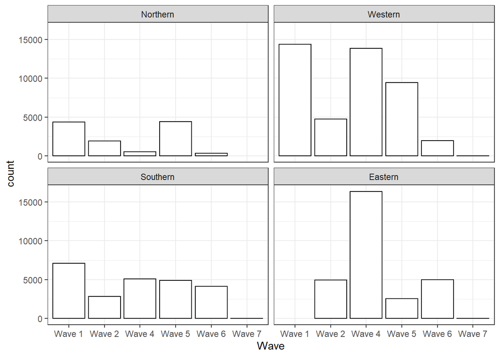

```r
ggplot(share.data.first.interview, aes(Wave)) + facet_wrap(region~.) + geom_bar(fill="white", color="black") + theme_bw()
```

#### 2.3.5.2 Cross-tabulations of other categorical variables

##### 2.3.5.2.1 Vigorous physical activities and other categorical variables

Vigorous PA was more common among men, participants with higher education, without chronic diseases and iadl limitations, not living alone (and in Nothern region).

###### 2.3.5.2.1.1 Vigorous PA and gender

```r
gmodels::CrossTable(share.data.first.interview.model$pa_vig, share.data.first.interview.model$gender, prop.chisq= FALSE, prop.c = FALSE, prop.t=FALSE)
```

```
##
##
##    Cell Contents
## |-------------------------|
## |                       N |
## |           N / Row Total |
## |-------------------------|
##
##
## Total Observations in Table:  104069
##
##
##                                         | share.data.first.interview.model$gender
## share.data.first.interview.model$pa_vig |      Male |    Female | Row Total |
## ----------------------------------------|-----------|-----------|-----------|
##                   More than once a week |     19449 |     17897 |     37346 |
##                                         |     0.521 |     0.479 |     0.359 |
## ----------------------------------------|-----------|-----------|-----------|
##                             Once a week |      6519 |      8094 |     14613 |
##                                         |     0.446 |     0.554 |     0.140 |
## ----------------------------------------|-----------|-----------|-----------|
##              One to three times a month |      4664 |      5339 |     10003 |
##                                         |     0.466 |     0.534 |     0.096 |
## ----------------------------------------|-----------|-----------|-----------|
##                   Hardly ever, or never |     17255 |     24852 |     42107 |
##                                         |     0.410 |     0.590 |     0.405 |
## ----------------------------------------|-----------|-----------|-----------|
##                            Column Total |     47887 |     56182 |    104069 |
## ----------------------------------------|-----------|-----------|-----------|
##
##
```

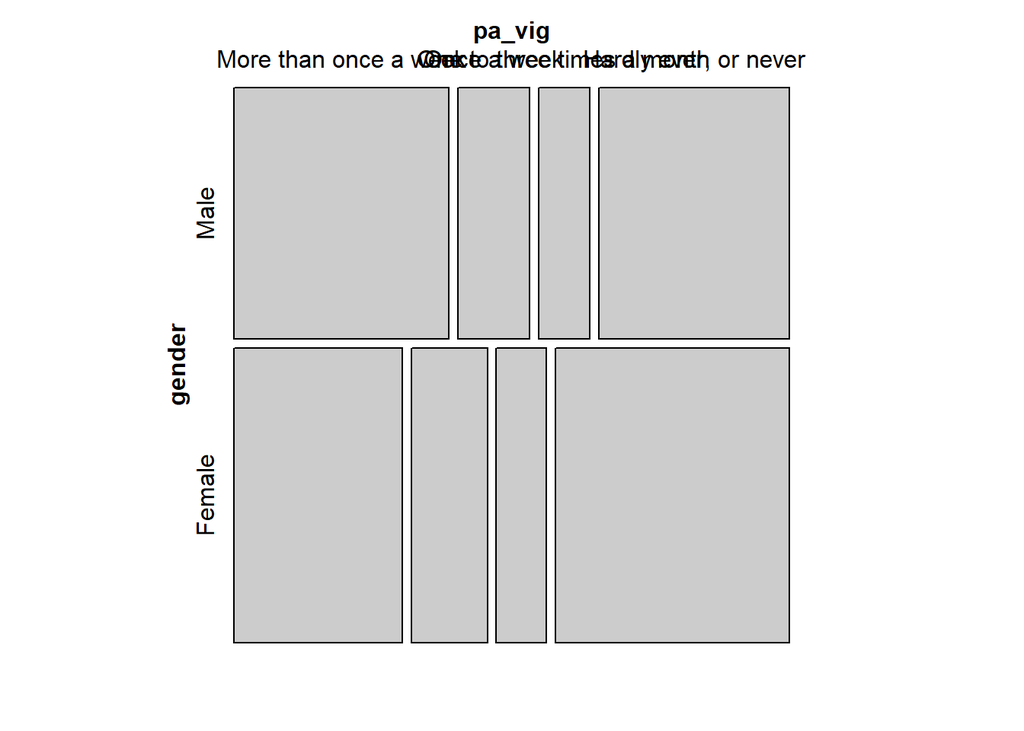

```r
mosaic(~ gender+ pa_vig, data=share.data.first.interview.model)
```

```r
#assoc(table(share.data.first.interview.model$education_imp, share.data.first.interview.model$region), legend=TRUE)
```

Women engaged less often in vigorous PA than men.

#### 2.3.5.3 Correlations between numerical/binary variables

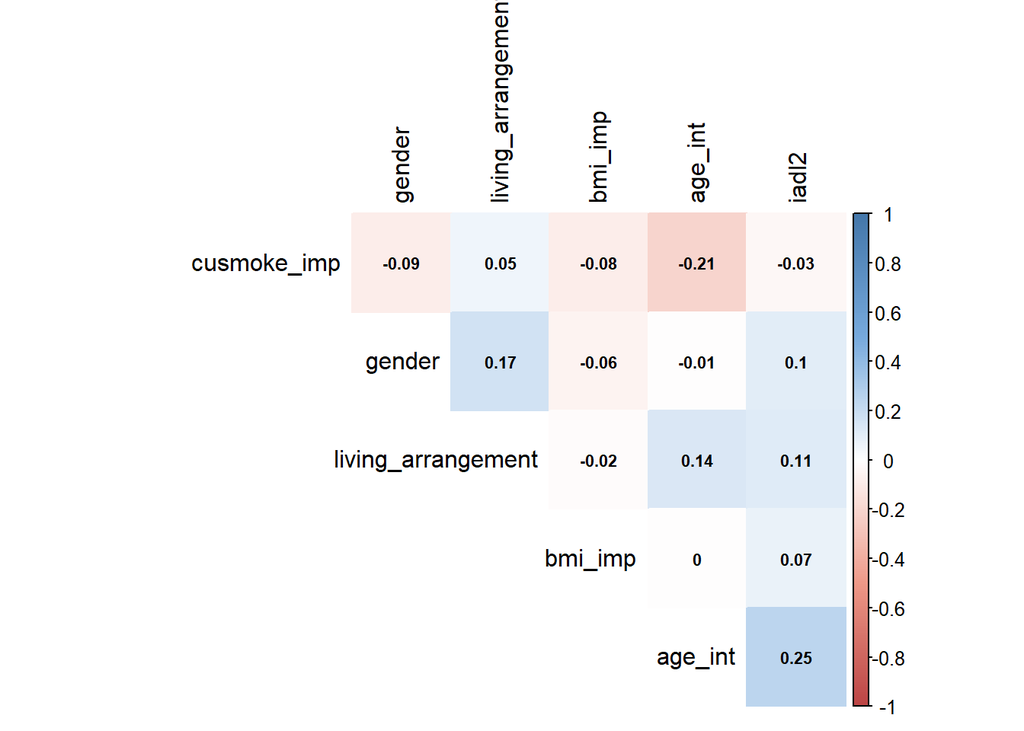

```r
corrs <- share.data.first.interview.model %>%
  dplyr::select(gender, age_int, bmi_imp, cusmoke_imp, iadl2, living_arrangement) %>%
  filter(complete.cases(.)) %>%
  dplyr::mutate_all(as.numeric)

M <- cor(corrs)
col <- colorRampPalette(c("#BB4444", "#EE9988", "#FFFFFF", "#77AADD", "#4477AA"))
corrplot(M, method = "color", col = col(200),
         type = "upper", order = "hclust", number.cex = .7,
         addCoef.col = "black", # Add coefficient of correlation
         tl.col = "black", tl.srt = 90, # Text label color and rotation
         # hide correlation coefficient on the principal diagonal
         diag = FALSE)
```

# 3 Statistical modelling

## 3.1 Additional descriptive statistics that compare the participants based on the outcome variable

### 3.1.1 Overall comparison of participants with EURO-D >=4 and others

Participants were categorized in those with and without depression, and compared by their baseline characteristics.

```r
s <-
    Hmisc::summaryM(
        Wave+ gender+ region + age_int+ age_int_cat+   education_imp +  bmi_imp + living_arrangement+  pa_vig +  cusmoke_imp +  dis_chronic_pres + iadl2  ~ eurodcat_imp_f,
        data = share.data.first.interview.model,
        overall = FALSE,
        test = FALSE
    )

Hmisc::html(
    s,
    caption = 'Baseline characteristics (overall)',
    exclude1 = TRUE,
    npct = 'both',
    digits = 3,
    prmsd = TRUE,
    brmsd = TRUE,
    msdsize = mu$smaller2
)
```

| Baseline characteristics (overall). | Baseline characteristics (overall). 0 *N=76057* | Baseline characteristics (overall). 1 *N=28012* |
| --- | --- | --- |
| Wave : Wave 1 | 0.25 <sup>19000</sup>/<sub>76057</sub> | 0.22 <sup>6069</sup>/<sub>28012</sub> |
| Wave 2 | 0.13 <sup>10135</sup>/<sub>76057</sub> | 0.13 <sup>3575</sup>/<sub>28012</sub> |
| Wave 4 | 0.31 <sup>23620</sup>/<sub>76057</sub> | 0.37 <sup>10251</sup>/<sub>28012</sub> |
| Wave 5 | 0.21 <sup>15656</sup>/<sub>76057</sub> | 0.18 <sup>4948</sup>/<sub>28012</sub> |
| Wave 6 | 0.10 <sup>7640</sup>/<sub>76057</sub> | 0.11 <sup>3167</sup>/<sub>28012</sub> |
| Wave 7 | 0.00 <sup>6</sup>/<sub>76057</sub> | 0.00 <sup>2</sup>/<sub>28012</sub> |
| gender : Female | 0.49 <sup>37337</sup>/<sub>76057</sub> | 0.67 <sup>18845</sup>/<sub>28012</sub> |
| region : Northern | 0.12 <sup>9266</sup>/<sub>76057</sub> | 0.07 <sup>1993</sup>/<sub>28012</sub> |
| Western | 0.42 <sup>32308</sup>/<sub>76057</sub> | 0.37 <sup>10324</sup>/<sub>28012</sub> |
| Southern | 0.21 <sup>15835</sup>/<sub>76057</sub> | 0.25 <sup>6913</sup>/<sub>28012</sub> |
| Eastern | 0.25 <sup>18648</sup>/<sub>76057</sub> | 0.31 <sup>8782</sup>/<sub>28012</sub> |
| age_int | 55.00 62.00 70.00 63.27 ± 9.26 | 56.00 64.00 73.00 64.84 ± 10.28 |
| age_int_cat : 50-59 | 0.40 <sup>30797</sup>/<sub>76057</sub> | 0.38 <sup>10507</sup>/<sub>28012</sub> |
| 60-69 | 0.34 <sup>25618</sup>/<sub>76057</sub> | 0.29 <sup>8091</sup>/<sub>28012</sub> |
| 70-80 | 0.21 <sup>16036</sup>/<sub>76057</sub> | 0.25 <sup>6970</sup>/<sub>28012</sub> |
| 80+ | 0.05 <sup>3606</sup>/<sub>76057</sub> | 0.09 <sup>2444</sup>/<sub>28012</sub> |
| education_imp : Low | 0.38 <sup>29244</sup>/<sub>76057</sub> | 0.52 <sup>14567</sup>/<sub>28012</sub> |
| Medium | 0.38 <sup>29253</sup>/<sub>76057</sub> | 0.33 <sup>9225</sup>/<sub>28012</sub> |
| High | 0.23 <sup>17252</sup>/<sub>76057</sub> | 0.15 <sup>4084</sup>/<sub>28012</sub> |
| Other | 0.00 <sup>308</sup>/<sub>76057</sub> | 0.00 <sup>136</sup>/<sub>28012</sub> |
| bmi_imp | 23.83 26.12 29.04 26.68 ± 4.32 | 23.73 26.56 29.97 27.19 ± 5.13 |
| living_arrangement : Living alone | 0.24 <sup>18406</sup>/<sub>76057</sub> | 0.36 <sup>10036</sup>/<sub>28012</sub> |
| pa_vig : More than once a week | 0.40 <sup>30071</sup>/<sub>76057</sub> | 0.26 <sup>7275</sup>/<sub>28012</sub> |
| Once a week | 0.15 <sup>11509</sup>/<sub>76057</sub> | 0.11 <sup>3104</sup>/<sub>28012</sub> |
| One to three times a month | 0.10 <sup>7655</sup>/<sub>76057</sub> | 0.08 <sup>2348</sup>/<sub>28012</sub> |
| Hardly ever, or never | 0.35 <sup>26822</sup>/<sub>76057</sub> | 0.55 <sup>15285</sup>/<sub>28012</sub> |
| cusmoke_imp : Yes | 0.20 <sup>14842</sup>/<sub>76057</sub> | 0.21 <sup>5782</sup>/<sub>28012</sub> |
| dis_chronic_pres : 0 | 0.52 <sup>39478</sup>/<sub>76057</sub> | 0.36 <sup>10138</sup>/<sub>28012</sub> |
| 1 | 0.33 <sup>25343</sup>/<sub>76057</sub> | 0.35 <sup>9825</sup>/<sub>28012</sub> |
| 2+ | 0.15 <sup>11236</sup>/<sub>76057</sub> | 0.29 <sup>8049</sup>/<sub>28012</sub> |
| iadl2 : 1+ iadl limitations | 0.09 <sup>6740</sup>/<sub>76057</sub> | 0.30 <sup>8429</sup>/<sub>28012</sub> |

*a* *b* *c* represent the lower quartile *a*, the median *b*, and the upper quartile *c* for continuous variables. *x ± s* represents X ± 1 SD.

Depression was reported for approximately 19% of men and 34% of women.

### 3.1.2 Distribution of outcome by gender

```r
s <-
    Hmisc::summaryM(
        eurod + eurodcat_imp_f~ gender ,
        data = share.data.first.interview.model,
        overall = FALSE,
        test = FALSE
    )

Hmisc::html(
    s,
    caption = 'Outcome distribution by gender',
    exclude1 = TRUE,
    npct = 'both',
    digits = 3,
    prmsd = TRUE,
    brmsd = TRUE,
    msdsize = mu$smaller2
)
```

| Outcome distribution by gender. | Outcome distribution by gender. N | Outcome distribution by gender. Male *N=47887* | Outcome distribution by gender. Female *N=56182* |
| --- | --- | --- | --- |
| eurod | 103207 | 0.00 1.00 3.00 1.95 ± 2.02 | 1.00 2.00 4.00 2.81 ± 2.38 |
| eurodcat_imp_f | 104069 | 0.19 <sup>9167</sup>/<sub>47887</sub> | 0.34 <sup>18845</sup>/<sub>56182</sub> |

*a* *b* *c* represent the lower quartile *a*, the median *b*, and the upper quartile *c* for continuous variables. *x ± s* represents X ± 1 SD. *N* is the number of non-missing values.

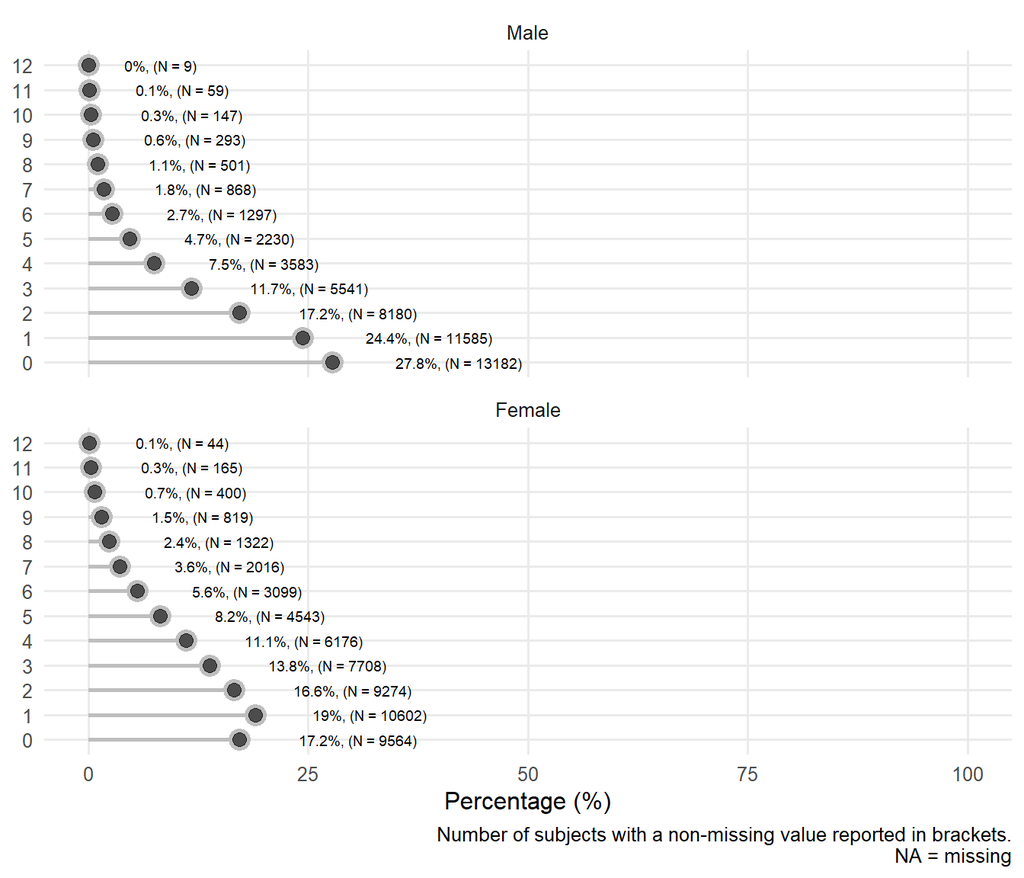

Distribution of depression score (point scale) by gender

```r
share.data.first.interview.model %>%
  dplyr::filter(!(is.na(eurod))) %>%
  dplyr::select(eurod, gender) %>%
  dplyr::mutate_all(forcats::as_factor) %>%
  dplyr::mutate_all(forcats::fct_explicit_na, "NA") %>%
  tidyr::pivot_longer(
    -gender,
    names_to = "var",
    values_to = "value",
    values_drop_na = FALSE
  ) %>%
  dplyr::group_by(gender, var, value) %>%
  dplyr::summarize(N = n()) %>%
  dplyr::mutate(
    freq = N / sum(N),
    pct = round((freq * 100), 1),#,
    value = as_factor(value),
    axis_lab = as_factor(paste0(pct, '%, (N = ', N, ')'))
  ) %>%
  ggplot(aes(x = value,
             y = pct,
             label = axis_lab)) +
 geom_text(size = 2.5, hjust = -0.5) +
  geom_pointrange(
    aes(ymin = 0, ymax = pct),
    alpha = 1,
    size = 1,
    color = "grey"
  ) +
  geom_point(color = "black",
             alpha = 0.6,
             size = 3) +
  ylab("Percentage (%)") +
  scale_y_continuous(limits = c(0, 100)) +
  labs(caption = "Number of subjects with a non-missing value reported in brackets.\nNA = missing") +
  coord_flip() +
  theme_minimal(base_size = 12) +
  theme(axis.title.y = element_blank(),
        panel.grid.minor = element_blank()) +
  facet_wrap( ~ gender, scales = "free_y", ncol = 1)
```

#### 3.1.2.1 Depression (binary)

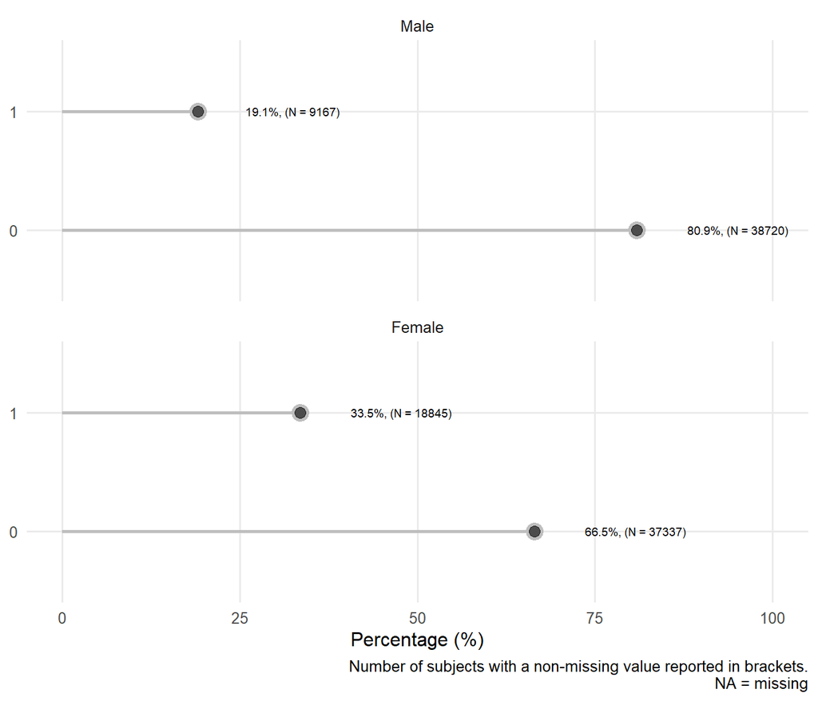

Distribution of depression (binary) by gender

```r
share.data.first.interview.model %>%
  dplyr::filter(!(is.na(eurodcat_imp_f))) %>%
  dplyr::select(eurodcat_imp_f, gender) %>%
  dplyr::mutate_all(forcats::as_factor) %>%
  dplyr::mutate_all(forcats::fct_explicit_na, "NA") %>%
  tidyr::pivot_longer(
    -gender,
    names_to = "var",
    values_to = "value",
    values_drop_na = FALSE
  ) %>%
  dplyr::group_by(gender, var, value) %>%
  dplyr::summarize(N = n()) %>%
  dplyr::mutate(
    freq = N / sum(N),
    pct = round((freq * 100), 1),
    value = as_factor(value),
    axis_lab = as_factor(paste0(pct, '%, (N = ', N, ')'))
  ) %>%
  ggplot(aes(x = value,
             y = pct,
             label = axis_lab)) +
 geom_text(size = 2.5, hjust = -0.5) +
  geom_pointrange(
    aes(ymin = 0, ymax = pct),
    alpha = 1,
    size = 1,
    color = "grey"
  ) +
  geom_point(color = "black",
             alpha = 0.6,
             size = 3) +
  ylab("Percentage (%)") +
  scale_y_continuous(limits = c(0, 100)) +
  labs(caption = "Number of subjects with a non-missing value reported in brackets.\nNA = missing") +
  coord_flip() +
  theme_minimal(base_size = 12) +
  theme(axis.title.y = element_blank(),
        panel.grid.minor = element_blank()) +
  facet_wrap( ~ gender, scales = "free_y", ncol = 1)
```

### 3.1.3 Distribution of outcome by age category

```r
s <-
    Hmisc::summaryM(
        eurod + eurodcat_imp_f~ age_int_cat ,
        data = share.data.first.interview.model,
        overall = FALSE,
        test = FALSE
    )

Hmisc::html(
    s,
    caption = 'Outcome distribution by gender',
    exclude1 = TRUE,
    npct = 'both',
    digits = 3,
    prmsd = TRUE,
    brmsd = TRUE,
    msdsize = mu$smaller2
)
```

| Outcome distribution by gender. | Outcome distribution by gender. N | Outcome distribution by gender. 50-59 *N=41304* | Outcome distribution by gender. 60-69 *N=33709* | Outcome distribution by gender. 70-80 *N=23006* | Outcome distribution by gender. 80+ *N=6050* |
| --- | --- | --- | --- | --- | --- |
| eurod | 103207 | 1.00 2.00 4.00 2.32 ± 2.22 | 1.00 2.00 3.00 2.24 ± 2.17 | 1.00 2.00 4.00 2.65 ± 2.36 | 1.00 3.00 5.00 3.22 ± 2.51 |
| eurodcat_imp_f | 104069 | 0.25 <sup>10507</sup>/<sub>41304</sub> | 0.24 <sup>8091</sup>/<sub>33709</sub> | 0.30 <sup>6970</sup>/<sub>23006</sub> | 0.40 <sup>2444</sup>/<sub>6050</sub> |

*a* *b* *c* represent the lower quartile *a*, the median *b*, and the upper quartile *c* for continuous variables. *x ± s* represents X ± 1 SD. *N* is the number of non-missing values.

#### 3.1.3.1 Depression score

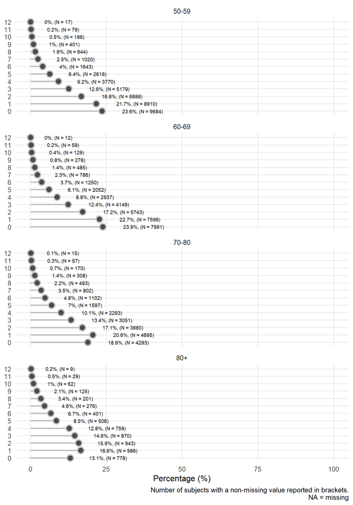

Distribution of depression score (point scale) by age (categorical)

```r
share.data.first.interview.model %>%
  dplyr::filter(!(is.na(eurod))) %>%
  dplyr::select(eurod, age_int_cat) %>%
  dplyr::mutate_all(forcats::as_factor) %>%
  dplyr::mutate_all(forcats::fct_explicit_na, "NA") %>%
  tidyr::pivot_longer(
    -age_int_cat,
    names_to = "var",
    values_to = "value",
    values_drop_na = FALSE
  ) %>%
  dplyr::group_by(age_int_cat, var, value) %>%
  dplyr::summarize(N = n()) %>%
  dplyr::mutate(
    freq = N / sum(N),
    pct = round((freq * 100), 1),
    value = as_factor(value),
    axis_lab = as_factor(paste0(pct, '%, (N = ', N, ')'))
  ) %>%
  ggplot(aes(x = value,
             y = pct,
             label = axis_lab)) +
 geom_text(size = 2.5, hjust = -0.5) +
  geom_pointrange(
    aes(ymin = 0, ymax = pct),
    alpha = 1,
    size = 1,
    color = "grey"
  ) +
  geom_point(color = "black",
             alpha = 0.6,
             size = 3) +
  ylab("Percentage (%)") +
  scale_y_continuous(limits = c(0, 100)) +
  labs(caption = "Number of subjects with a non-missing value reported in brackets.\nNA = missing") +
  coord_flip() +
  theme_minimal(base_size = 12) +
  theme(axis.title.y = element_blank(),
        panel.grid.minor = element_blank()) +
  facet_wrap( ~ age_int_cat, scales = "free_y", ncol = 1)
```

#### 3.1.3.2 Depression (binary)

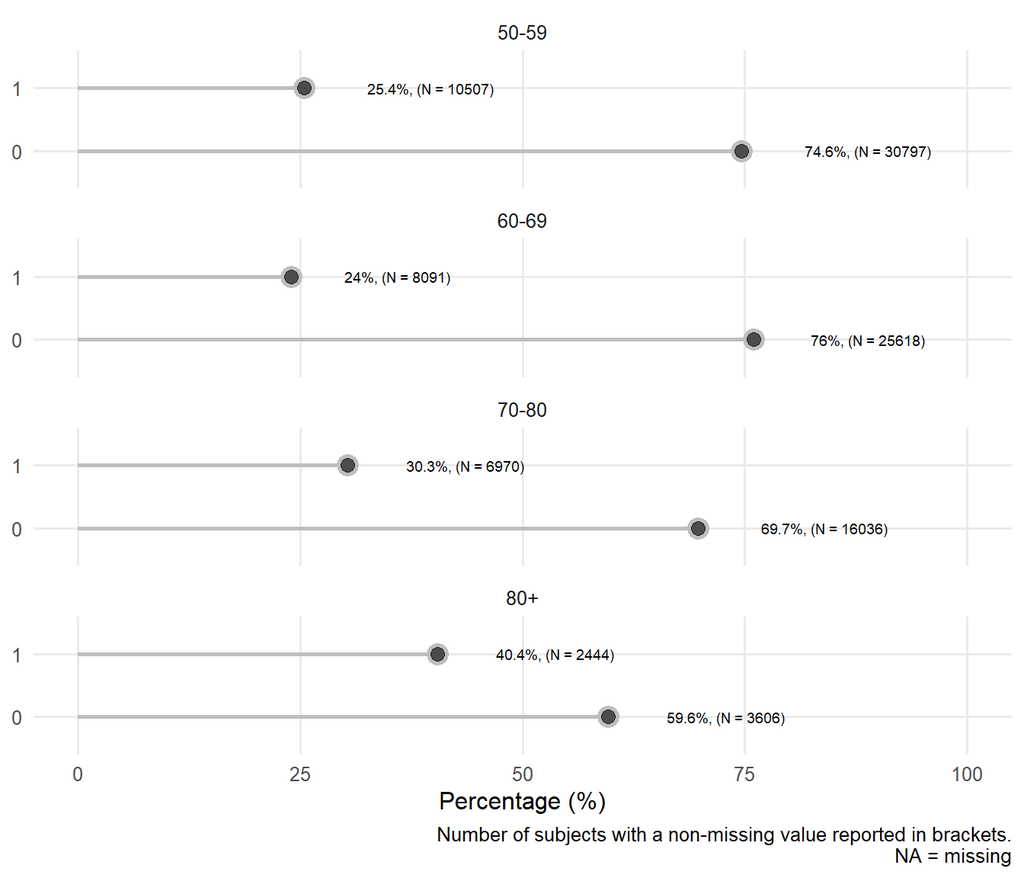

Distribution of depression (binary) by age (categorical)

```r
share.data.first.interview.model %>%
  dplyr::filter(!(is.na(eurodcat_imp_f))) %>%
  dplyr::select(eurodcat_imp_f, age_int_cat) %>%
  dplyr::mutate_all(forcats::as_factor) %>%
  dplyr::mutate_all(forcats::fct_explicit_na, "NA") %>%
  tidyr::pivot_longer(
    -age_int_cat,
    names_to = "var",
    values_to = "value",
    values_drop_na = FALSE
  ) %>%
  dplyr::group_by(age_int_cat, var, value) %>%
  dplyr::summarize(N = n()) %>%
  dplyr::mutate(
    freq = N / sum(N),
    pct = round((freq * 100), 1),
    value = as_factor(value),
    axis_lab = as_factor(paste0(pct, '%, (N = ', N, ')'))
  ) %>%
  ggplot(aes(x = value,
             y = pct,
             label = axis_lab)) +
 geom_text(size = 2.5, hjust = -0.5) +
  geom_pointrange(
    aes(ymin = 0, ymax = pct),
    alpha = 1,
    size = 1,
    color = "grey"
  ) +
  geom_point(color = "black",
             alpha = 0.6,
             size = 3) +
  ylab("Percentage (%)") +
  scale_y_continuous(limits = c(0, 100)) +
  labs(caption = "Number of subjects with a non-missing value reported in brackets.\nNA = missing") +
  coord_flip() +
  theme_minimal(base_size = 12) +
  theme(axis.title.y = element_blank(),
        panel.grid.minor = element_blank()) +
  facet_wrap( ~ age_int_cat, scales = "free_y", ncol = 1)
```

### 3.1.4 Distribution of outcome by region

```r
s <-
    Hmisc::summaryM(
        eurod + eurodcat_imp_f~ region ,
        data = share.data.first.interview.model,
        overall = FALSE,
        test = FALSE
    )

Hmisc::html(
    s,
    caption = 'Outcome distribution by gender',
    exclude1 = TRUE,
    npct = 'both',
    digits = 3,
    prmsd = TRUE,
    brmsd = TRUE,
    msdsize = mu$smaller2
)
```

| Outcome distribution by gender. | Outcome distribution by gender. N | Outcome distribution by gender. Northern *N=11259* | Outcome distribution by gender. Western *N=42632* | Outcome distribution by gender. Southern *N=22748* | Outcome distribution by gender. Eastern *N=27430* |
| --- | --- | --- | --- | --- | --- |
| eurod | 103207 | 0.00 1.00 3.00 1.86 ± 1.88 | 1.00 2.00 3.00 2.26 ± 2.13 | 1.00 2.00 4.00 2.62 ± 2.51 | 1.00 2.00 4.00 2.72 ± 2.34 |
| eurodcat_imp_f | 104069 | 0.18 <sup>1993</sup>/<sub>11259</sub> | 0.24 <sup>10324</sup>/<sub>42632</sub> | 0.30 <sup>6913</sup>/<sub>22748</sub> | 0.32 <sup>8782</sup>/<sub>27430</sub> |

*a* *b* *c* represent the lower quartile *a*, the median *b*, and the upper quartile *c* for continuous variables. *x ± s* represents X ± 1 SD. *N* is the number of non-missing values.

#### 3.1.4.1 Depression score

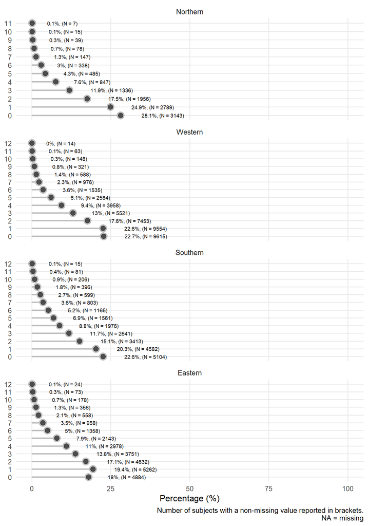

```r
share.data.first.interview.model %>%
  dplyr::filter(!(is.na(eurod))) %>%
  dplyr::select(eurod, region) %>%
  dplyr::mutate_all(forcats::as_factor) %>%
  dplyr::mutate_all(forcats::fct_explicit_na, "NA") %>%
  tidyr::pivot_longer(
    -region,
    names_to = "var",
    values_to = "value",
    values_drop_na = FALSE
  ) %>%
  dplyr::group_by(region, var, value) %>%
  dplyr::summarize(N = n()) %>%
  dplyr::mutate(
    freq = N / sum(N),
    pct = round((freq * 100), 1),
    value = as_factor(value),
    axis_lab = as_factor(paste0(pct, '%, (N = ', N, ')'))
  ) %>%
  ggplot(aes(x = value,
             y = pct,
             label = axis_lab)) +
 geom_text(size = 2.5, hjust = -0.5) +
  geom_pointrange(
    aes(ymin = 0, ymax = pct),
    alpha = 1,
    size = 1,
    color = "grey"
  ) +
  geom_point(color = "black",
             alpha = 0.6,
             size = 3) +
  ylab("Percentage (%)") +
  scale_y_continuous(limits = c(0, 100)) +
  labs(caption = "Number of subjects with a non-missing value reported in brackets.\nNA = missing") +
  coord_flip() +
  theme_minimal(base_size = 12) +
  theme(axis.title.y = element_blank(),
        panel.grid.minor = element_blank()) +
  facet_wrap( ~ region, scales = "free_y", ncol = 1)
```

### 3.1.5 Distribution of depression (binary) by region

```r
s <-
  Hmisc::summaryM(
    eurodcat_imp ~ region ,
   data = share.data.first.interview.model,
    overall = FALSE,
    test = FALSE
  )

Hmisc::html(
  s,
  caption = 'Baseline characteristics by region',
  exclude1 = TRUE,
  npct = 'both',
  digits = 3,
  prmsd = TRUE,
  brmsd = TRUE,
  msdsize = mu$smaller2
)
```

| Baseline characteristics by region. | Baseline characteristics by region. Northern *N=11259* | Baseline characteristics by region. Western *N=42632* | Baseline characteristics by region. Southern *N=22748* | Baseline characteristics by region. Eastern *N=27430* |
| --- | --- | --- | --- | --- |
| eurodcat_imp | 0.18 <sup>1993</sup>/<sub>11259</sub> | 0.24 <sup>10324</sup>/<sub>42632</sub> | 0.30 <sup>6913</sup>/<sub>22748</sub> | 0.32 <sup>8782</sup>/<sub>27430</sub> |

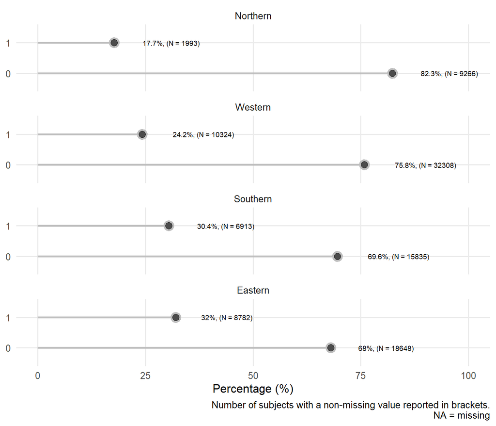

Distribution of depression (binary) by region

```r
share.data.first.interview.model %>%
  dplyr::filter(!(is.na(eurodcat_imp_f))) %>%
  dplyr::select(eurodcat_imp_f, region) %>%
  dplyr::mutate_all(forcats::as_factor) %>%
  dplyr::mutate_all(forcats::fct_explicit_na, "NA") %>%
  tidyr::pivot_longer(
    -region,
    names_to = "var",
    values_to = "value",
    values_drop_na = FALSE
  ) %>%
  dplyr::group_by(region, var, value) %>%
  dplyr::summarize(N = n()) %>%
  dplyr::mutate(
    freq = N / sum(N),
    pct = round((freq * 100), 1),
    value = as_factor(value),
    axis_lab = as_factor(paste0(pct, '%, (N = ', N, ')'))
  ) %>%
  ggplot(aes(x = value,
             y = pct,
             label = axis_lab)) +
 geom_text(size = 2.5, hjust = -0.5) +
  geom_pointrange(
    aes(ymin = 0, ymax = pct),
    alpha = 1,
    size = 1,
    color = "grey"
  ) +
  geom_point(color = "black",
             alpha = 0.6,
             size = 3) +
  ylab("Percentage (%)") +
  scale_y_continuous(limits = c(0, 100)) +
  labs(caption = "Number of subjects with a non-missing value reported in brackets.\nNA = missing") +
  coord_flip() +
  theme_minimal(base_size = 12) +
  theme(axis.title.y = element_blank(),
        panel.grid.minor = element_blank()) +
  facet_wrap( ~  region, scales = "free_y", ncol = 1)
```

### 3.1.6 Distribution of outcome by region and gender

```r
s <-
    Hmisc::summaryM(
        eurod + eurodcat_imp_f~ region + gender ,
        data = share.data.first.interview.model,
        overall = FALSE,
        test = FALSE
    )

Hmisc::html(
    s,
    caption = 'Outcome distribution by gender',
    exclude1 = TRUE,
    npct = 'both',
    digits = 3,
    prmsd = TRUE,
    brmsd = TRUE,
    msdsize = mu$smaller2
)
```

| Outcome distribution by gender. | Outcome distribution by gender. N | Outcome distribution by gender. Northern *N=5874* | Outcome distribution by gender. Western *N=22759* | Outcome distribution by gender. Southern *N=12076* | Outcome distribution by gender. Eastern *N=15473* |
| --- | --- | --- | --- | --- | --- |
| Male |  |  |  |  |  |
| eurod | 47475 | 0.00 1.00 2.00 1.53 ± 1.69 | 0.00 1.00 3.00 1.86 ± 1.95 | 0.00 1.00 3.00 2.03 ± 2.18 | 1.00 2.00 3.00 2.25 ± 2.10 |
| eurodcat_imp_f | 47887 | 0.12 <sup>646</sup>/<sub>5385</sub> | 0.17 <sup>3460</sup>/<sub>19873</sub> | 0.21 <sup>2189</sup>/<sub>10672</sub> | 0.24 <sup>2872</sup>/<sub>11957</sub> |
| Female |  |  |  |  |  |
| eurod | 55732 | 1.00 2.00 3.00 2.16 ± 1.99 | 1.00 2.00 4.00 2.62 ± 2.21 | 1.00 3.00 5.00 3.15 ± 2.66 | 1.00 3.00 5.00 3.08 ± 2.45 |
| eurodcat_imp_f | 56182 | 0.23 <sup>1347</sup>/<sub>5874</sub> | 0.30 <sup>6864</sup>/<sub>22759</sub> | 0.39 <sup>4724</sup>/<sub>12076</sub> | 0.38 <sup>5910</sup>/<sub>15473</sub> |

*a* *b* *c* represent the lower quartile *a*, the median *b*, and the upper quartile *c* for continuous variables. *x ± s* represents X ± 1 SD. *N* is the number of non-missing values.

### 3.1.7 Distribution of outcome by region, gender and age category

```r
s <-
    Hmisc::summaryM(
        eurod + eurodcat_imp_f~  age_int_cat+ gender+ region ,
        data = share.data.first.interview.model,
        overall = FALSE,
        test = FALSE
    )

Hmisc::html(
    s,
    caption = 'Outcome distribution by gender',
    exclude1 = TRUE,
    npct = 'both',
    digits = 3,
    prmsd = TRUE,
    brmsd = TRUE,
    msdsize = mu$smaller2
)
```

| Outcome distribution by gender. | Outcome distribution by gender. N | Outcome distribution by gender. 50-59 *N=5685* | Outcome distribution by gender. 60-69 *N=5052* | Outcome distribution by gender. 70-80 *N=3738* | Outcome distribution by gender. 80+ *N=998* |
| --- | --- | --- | --- | --- | --- |
| Male Northern |  |  |  |  |  |
| eurod | 5351 | 0.00 1.00 2.00 1.55 ± 1.74 | 0.00 1.00 2.00 1.38 ± 1.55 | 0.00 1.00 2.00 1.58 ± 1.72 | 1.00 2.00 3.00 2.01 ± 1.86 |
| eurodcat_imp_f | 5385 | 0.13 <sup>263</sup>/<sub>2056</sub> | 0.09 <sup>171</sup>/<sub>1825</sub> | 0.13 <sup>153</sup>/<sub>1187</sub> | 0.19 <sup>59</sup>/<sub>317</sub> |
| Female Northern |  |  |  |  |  |
| eurod | 5829 | 1.00 2.00 4.00 2.27 ± 2.08 | 0.00 1.00 3.00 1.94 ± 1.87 | 1.00 2.00 3.00 2.16 ± 1.94 | 1.00 2.00 4.00 2.75 ± 2.15 |
| eurodcat_imp_f | 5874 | 0.26 <sup>629</sup>/<sub>2438</sub> | 0.18 <sup>349</sup>/<sub>1925</sub> | 0.22 <sup>261</sup>/<sub>1199</sub> | 0.35 <sup>108</sup>/<sub>312</sub> |
| Male Western |  |  |  |  |  |
| eurod | 19731 | 0.00 1.00 3.00 1.90 ± 1.99 | 0.00 1.00 3.00 1.71 ± 1.84 | 0.00 1.00 3.00 1.90 ± 1.94 | 1.00 2.00 3.00 2.28 ± 2.09 |
| eurodcat_imp_f | 19873 | 0.18 <sup>1480</sup>/<sub>8231</sub> | 0.15 <sup>998</sup>/<sub>6466</sub> | 0.18 <sup>736</sup>/<sub>4173</sub> | 0.25 <sup>246</sup>/<sub>1003</sub> |
| Female Western |  |  |  |  |  |
| eurod | 22599 | 1.00 2.00 4.00 2.62 ± 2.25 | 1.00 2.00 4.00 2.47 ± 2.13 | 1.00 2.00 4.00 2.65 ± 2.20 | 1.00 3.00 4.75 3.17 ± 2.31 |
| eurodcat_imp_f | 22759 | 0.30 <sup>2960</sup>/<sub>9782</sub> | 0.28 <sup>1893</sup>/<sub>6866</sub> | 0.30 <sup>1435</sup>/<sub>4712</sub> | 0.41 <sup>576</sup>/<sub>1399</sub> |
| Male Southern |  |  |  |  |  |
| eurod | 10569 | 0.00 1.00 3.00 1.74 ± 2.01 | 0.00 1.00 3.00 1.93 ± 2.11 | 1.00 2.00 3.00 2.34 ± 2.31 | 1.00 3.00 4.00 3.12 ± 2.50 |
| eurodcat_imp_f | 10672 | 0.16 <sup>646</sup>/<sub>3947</sub> | 0.19 <sup>658</sup>/<sub>3551</sub> | 0.25 <sup>635</sup>/<sub>2537</sub> | 0.39 <sup>250</sup>/<sub>637</sub> |
| Female Southern |  |  |  |  |  |
| eurod | 11973 | 1.00 2.00 4.00 2.76 ± 2.51 | 1.00 2.00 5.00 3.06 ± 2.59 | 1.00 3.00 6.00 3.68 ± 2.78 | 2.00 4.00 6.00 4.31 ± 2.83 |
| eurodcat_imp_f | 12076 | 0.33 <sup>1621</sup>/<sub>4870</sub> | 0.38 <sup>1424</sup>/<sub>3784</sub> | 0.47 <sup>1250</sup>/<sub>2681</sub> | 0.58 <sup>429</sup>/<sub>741</sub> |
| Male Eastern |  |  |  |  |  |
| eurod | 11824 | 1.00 2.00 3.00 2.13 ± 2.03 | 0.00 2.00 3.00 2.05 ± 1.99 | 1.00 2.00 4.00 2.56 ± 2.23 | 1.00 3.00 4.00 3.00 ± 2.28 |
| eurodcat_imp_f | 11957 | 0.22 <sup>960</sup>/<sub>4295</sub> | 0.21 <sup>880</sup>/<sub>4240</sub> | 0.29 <sup>795</sup>/<sub>2779</sub> | 0.37 <sup>237</sup>/<sub>643</sub> |
| Female Eastern |  |  |  |  |  |
| eurod | 15331 | 1.00 2.00 4.00 2.85 ± 2.39 | 1.00 2.00 4.00 2.81 ± 2.32 | 1.75 3.00 5.00 3.50 ± 2.51 | 2.00 4.00 6.00 4.20 ± 2.71 |
| eurodcat_imp_f | 15473 | 0.34 <sup>1948</sup>/<sub>5685</sub> | 0.34 <sup>1718</sup>/<sub>5052</sub> | 0.46 <sup>1705</sup>/<sub>3738</sub> | 0.54 <sup>539</sup>/<sub>998</sub> |

*a* *b* *c* represent the lower quartile *a*, the median *b*, and the upper quartile *c* for continuous variables. *x ± s* represents X ± 1 SD. *N* is the number of non-missing values.

## 3.2 Results of data analysis

In the models the country effect were coded using the deviance coding - the coefficients estimate the difference between the mean of the country minus the grand mean. With the following code we define some variables that will be used for modeling, and define reference values for some categorical variables.

```r
#using sum/deviance coding for the country variable, the meaning of the coefficient is the mean of the country minus the grand mean
 mat <- contr.sum(length(levels(share.data.first.interview$country)))
colnames(mat)  <- levels(share.data.first.interview$country)[-length(levels(share.data.first.interview$country))]
contrasts(share.data.first.interview$country) <- mat

#data transformations to enhance the readability of the outputs
share.data.first.interview$age_int_10 <- share.data.first.interview$age_int/10
share.data.first.interview$bmi_imp_10 <- share.data.first.interview$bmi_imp/10
share.data.first.interview$height_10 <- share.data.first.interview$height/10


#education, reference High
share.data.first.interview$education_imp <- factor(share.data.first.interview$education_imp, levels=c("High", "Medium", "Low", "Other"))

#pa_vig, reference More than once a week
share.data.first.interview$pa_vig <- factor(share.data.first.interview$pa_vig, levels = c("More than once a week", "Once a week", "One to three times a month",  "Hardly ever, or never") )
  #relevel(share.data.first.interview$pa_vig, "More than once a week")


#setting to factor the outcome
#share.data.first.interview$eurodcat_imp_f <- as.factor(share.data.first.interview$eurodcat_imp)



#explanatory = c("age_int_10", "gender", "education", "bmi_10", "height_10", "living_arrangement", "pa_vig", "cusmoke_imp", "dis_chronic_pres", "iadl2", "country" )

explanatory = c("age_int", "age_int_cat", "gender", "education", "bmi", "height", "living_arrangement", "pa_vig", "cusmoke_imp", "dis_chronic_pres", "iadl2", "country" )
dependent = "eurodcat_imp_f"
```

## 3.3 Model fitting

We considered two types of logistic models

- **unadjusted models**: including two-way interactions between age, gender and geographic region (unadjusted models);
- **adjusted models**: in addition to age, gender, and region as in the “unadjusted models” further adjusting by known risk factors (education, BMI, smoking, presence of chronic disease, vigorous physical activity, living arrangement).

Age was centered at 50 years and modeled - as a **linear** effect - as a **non-linear** effect with restricted cubic splines (rcs) and 5 knots placed at ages: 51, 56, 62, 70 and 81, using the default choice for the quantiles.

In the adjusted models the estimated probabilities were obtained using fixed levels of the risk factors (modal value for categorical covariates: non-smokers, low education, without chronic diseases, vigorous PA hardly ever, living with partner, and using median gender-specific BMI (25.9 for women and 26.6 for men).

```r
#definition of standardized age for ease of interpretation of the coefficients
share.data.first.interview<- share.data.first.interview.model %>% mutate (age_int_stand = age_int - 50)
```

The geographic region was modeled - by grouping the countries in four **regions** (Northern, Western, Southern, Eastern)

Some of the coefficients of the estimated model are difficult to interpret, due to the use of restricted cubic splines and of interactions. Therefore, graphical displays of the estimated probabilities are used to present the results, rather than a table with the estimated coefficients. When RCS are used, the estimated coefficients/odds ratios (OR) are not presented only age and its interactions.

The purpose of modeling the linear effect of age is to evaluate the impact of the choice of functional forms on the estimated probability of depression.

### 3.3.1 Models with geographic regions

#### 3.3.1.1 Unadjusted model with rcs for age

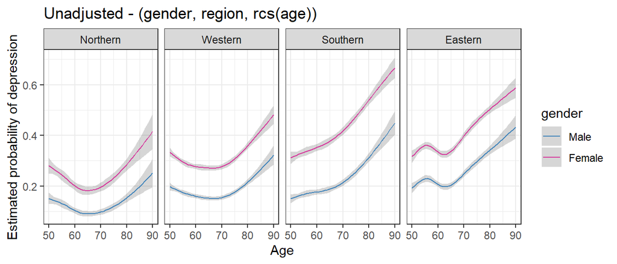

```r
my.mod <- glm(eurodcat_imp ~ rcs(age_int_stand) + gender + region +
                       rcs(age_int_stand):region + rcs(age_int_stand):gender + gender:region ,
                                             data=share.data.first.interview, family="binomial",  x=TRUE, y=TRUE)

#save the spline terms in the complete data set for further use
share.data.first.interview <- share.data.first.interview %>% mutate(age1 = my.mod$x[,2],
                                                                    age2 = my.mod$x[,3],
                                                                    age3 = my.mod$x[,4],
                                                                    age4 = my.mod$x[,5])


# retrieve the location of knots used and assign them to Knots variable
Knots <- Hmisc::rcspline.eval(x = share.data.first.interview$age_int_stand, nk = 5, knots.only = TRUE)

#reproduces the spline values for age, expands for each integer value from 50 to 90
age = rcspline.eval(c(50:90)-50, knots=Knots)
age <- cbind.data.frame(age1=c(50:90)-50, age )
dimnames(age)[[2]] <- c("age1", "age2", "age3", "age4")






if(!is.null(my.mod$na.action)){
my.mod2 <- glm(eurodcat_imp ~ age1 + age2 + age3 + age4 + gender + region +
                      age1:region + age2:region + age3:region + age4:region +
                       age1:gender + age2:gender + age3:gender + age4:gender +
                       gender:region ,
                        data=share.data.first.interview[-my.mod$na.action,], family="binomial",  x=TRUE, y=TRUE)} else {
 my.mod2 <- glm(eurodcat_imp ~ age1 + age2 + age3 + age4 + gender + region +
                      age1:region + age2:region + age3:region + age4:region +
                       age1:gender + age2:gender + age3:gender + age4:gender +
                       gender:region ,
                        data=share.data.first.interview, family="binomial",  x=TRUE, y=TRUE)
}





#derive the data.frame containing the levels of the covariate, where the probabilities of depression estimated by the model will be derived
data.grid <- expand.grid(age1=age[,1], gender=levels(share.data.first.interview$gender), region=levels(share.data.first.interview$region))
data.grid <- left_join(data.grid, age, by="age1" )


data.grid.region <- data.grid


#defining also data grid for countries
data.grid.country <- expand.grid(age1=age[,1], gender=levels(share.data.first.interview$gender), country=levels(share.data.first.interview$country))
data.grid.country <- left_join(data.grid.country, age, by="age1" )




#derive the predicted probabilities
my.pred <- predict(my.mod2, newdata=data.grid, se.fit = TRUE, type="response")

#join the levels of the covariates and the predicted probabilities
my.pred.all <- cbind.data.frame(data.grid, my.pred)

#saving the estimates from the 2-way models
pred.age_unadjusted_region_rcs <- my.pred.all

ggplot(my.pred.all, aes(age1+50, fit, color=gender)) + geom_line() + facet_wrap(region~., ncol=4) + labs(x="Age", y="Estimated probability of depression") + scale_color_manual(values=c("#4699dd","#ff3db7" )) + ggtitle("Unadjusted - (gender, region, rcs(age))") +
  geom_ribbon(aes(ymin = fit - 1.96*se.fit, ymax = fit + 1.96*se.fit), alpha = 0.2, linetype=0) +  theme_bw()
```

```r
#my.pred.all %>% left_join(select(share.data.first.interview, starts_with("region")), by="region") %>% ggplot(aes(age1, fit, #color=gender))+ geom_point() + facet_grid(.~regionGroup) + labs(x="Age", y="Estimated probability of depression") + #scale_color_manual(values=c("#4699dd","#ff3db7" ))


anova(my.mod, test="Chi")
```

```
## Analysis of Deviance Table
##
## Model: binomial, link: logit
##
## Response: eurodcat_imp
##
## Terms added sequentially (first to last)
##
##
##                           Df Deviance Resid. Df Resid. Dev Pr(>Chi)
## NULL                                     104068     121226
## rcs(age_int_stand)         4      947    104064     120279  < 2e-16 ***
## gender                     1     2747    104063     117532  < 2e-16 ***
## region                     3     1105    104060     116427  < 2e-16 ***
## rcs(age_int_stand):region 12      284    104048     116142  < 2e-16 ***
## rcs(age_int_stand):gender  4        2    104044     116140     0.65
## gender:region              3       52    104041     116088  3.6e-11 ***
## ---
## Signif. codes:  0 '***' 0.001 '**' 0.01 '*' 0.05 '.' 0.1 ' ' 1
```

The regions differ mostly in the shape of the association between age and depression between ages 50 and 70, after 70 the probability of depression seems to increase in all regions. In Northern/Western countries the probability of depression slightly decreases between 50 and 70. In Southern countries the probability of depression increases at all considered ages, more sharply after 70, in Eastern countries there is an increase followed by a decrease shortly after 50 (a peak around 55).

At all ages and in all regions women had larger probability of depression; the interaction between gender and age was included in the model but there was little evidence that the interaction was significant (both from ANOVA and looking at the shape of the estimated age-gender specific probabilities); only in Southern region we noticed that the increase in probability of depression in older ages was sharper for men than for women.

#### 3.3.1.2 Adjusted model with rcs for age

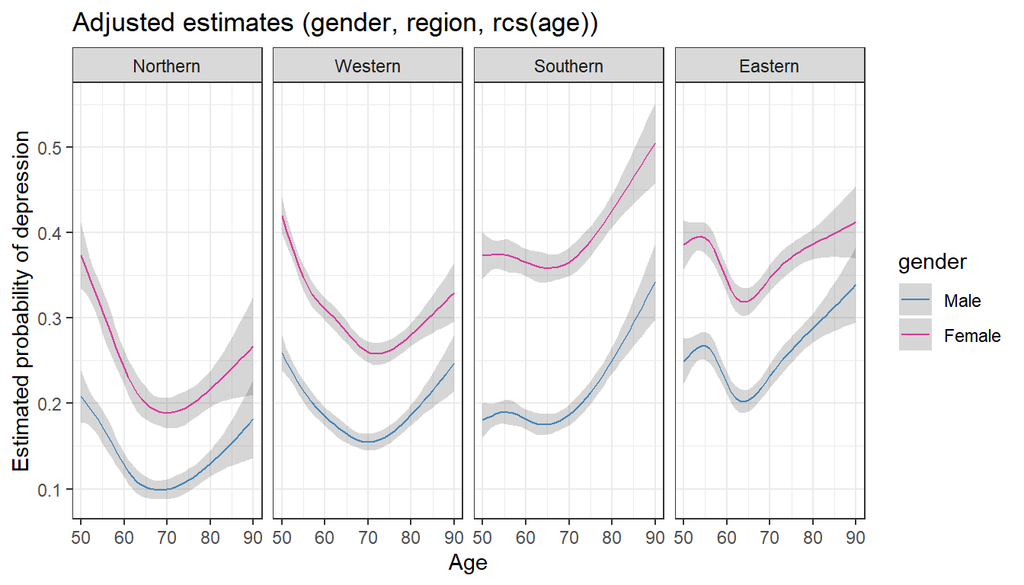

```r
my.mod2  <- glm(
  eurodcat_imp ~
    age1 + age2 + age3 + age4 + gender + region +
    bmi_imp + education_imp + cusmoke_imp + dis_chronic_pres +
    pa_vig + living_arrangement +
    age1:region + age2:region + age3:region + age4:region +
    age1:gender + age2:gender + age3:gender + age4:gender +
    gender:region,
  data = share.data.first.interview,
  family = "binomial",
  x = TRUE,
  y = TRUE
)



my.mod1  <- glm(
  eurodcat_imp ~
    rcspline.eval(age_int_stand, knots=Knots, inclx = TRUE) + gender + region +
    bmi_imp + education_imp + cusmoke_imp + dis_chronic_pres +
    pa_vig + living_arrangement +
     rcspline.eval(age_int_stand, knots=Knots, inclx = TRUE):region +
     rcspline.eval(age_int_stand, knots=Knots, inclx = TRUE):gender +
    gender:region,
  data = share.data.first.interview,
  family = "binomial",
  x = TRUE,
  y = TRUE
)



data.grid.adj <- expand.grid(age1=unique(share.data.first.interview$age1), gender=levels(share.data.first.interview$gender), region=levels(share.data.first.interview$region),
                         #overall mean
                         #bmi_10 = mean(share.data.first.interview$bmi_imp, na.rm=TRUE),

                      education_imp ="Low", cusmoke_imp="No",  dis_chronic_pres="0",
                        pa_vig = "Hardly ever, or never" ,  living_arrangement="Living with partner"
                         )


#using median bmi, separate evaluation by gender

data.grid.adj <- left_join(data.grid.adj,
          share.data.first.interview %>% group_by(gender) %>%
            #rename(age1 = age_int_stand) %>%
            summarise(bmi_imp=median(bmi_imp, na.rm=TRUE)),
           by=c("gender"))

data.grid.adj <- left_join(data.grid.adj, age, by="age1")
data.grid.adj.region <- data.grid.adj



#defining also data grid for countries
data.grid.adj.country <- expand.grid(age1=unique(share.data.first.interview$age1), gender=levels(share.data.first.interview$gender), country=levels(share.data.first.interview$country),
                         #overall mean
                         #bmi_10 = mean(share.data.first.interview$bmi_imp, na.rm=TRUE),

                      education_imp ="Low", cusmoke_imp="No",  dis_chronic_pres="0",
                        pa_vig = "Hardly ever, or never" ,  living_arrangement="Living with partner"
                         )
data.grid.adj.country <- left_join(data.grid.adj.country,
          share.data.first.interview %>% group_by(gender) %>%
            #rename(age1 = age_int_stand) %>%
            summarise(bmi_imp=median(bmi_imp, na.rm=TRUE)),
           by=c("gender"))

data.grid.adj.country <- left_join(data.grid.adj.country, age, by="age1")


#derive the predicted probabilities
my.pred <- predict(my.mod2, newdata=data.grid.adj, se.fit = TRUE, type="response")

#join the levels of the covariates and the predicted probabilities
my.pred.all <- cbind.data.frame(data.grid.adj, my.pred)

#saving the estimates from the 2-way models
pred.age_adjusted_region_rcs <- my.pred.all

ggplot(my.pred.all, aes(age1+50, fit, color=gender)) + geom_line() + facet_wrap(region~., ncol=4) + labs(x="Age", y="Estimated probability of depression") + scale_color_manual(values=c("#4699dd","#ff3db7" )) + ggtitle("Adjusted estimates (gender, region, rcs(age))") +
  geom_ribbon(aes(ymin = fit - 1.96*se.fit, ymax = fit + 1.96*se.fit), alpha = 0.2, linetype=0) +  theme_bw()
```

```r
anova(my.mod1, test="Chi")
```

```
## Analysis of Deviance Table
##
## Model: binomial, link: logit
##
## Response: eurodcat_imp
##
## Terms added sequentially (first to last)
##
##
##                                                                  Df Deviance
## NULL
## rcspline.eval(age_int_stand, knots = Knots, inclx = TRUE)         4      947
## gender                                                            1     2747
## region                                                            3     1105
## bmi_imp                                                           1      279
## education_imp                                                     3      781
## cusmoke_imp                                                       1      196
## dis_chronic_pres                                                  2     2442
## pa_vig                                                            3     1285
## living_arrangement                                                1      424
## rcspline.eval(age_int_stand, knots = Knots, inclx = TRUE):region 12      250
## rcspline.eval(age_int_stand, knots = Knots, inclx = TRUE):gender  4       16
## gender:region                                                     3       77
##                                                                  Resid. Df
## NULL                                                                104068
## rcspline.eval(age_int_stand, knots = Knots, inclx = TRUE)           104064
## gender                                                              104063
## region                                                              104060
## bmi_imp                                                             104059
## education_imp                                                       104056
## cusmoke_imp                                                         104055
## dis_chronic_pres                                                    104053
## pa_vig                                                              104050
## living_arrangement                                                  104049
## rcspline.eval(age_int_stand, knots = Knots, inclx = TRUE):region    104037
## rcspline.eval(age_int_stand, knots = Knots, inclx = TRUE):gender    104033
## gender:region                                                       104030
##                                                                  Resid. Dev
## NULL                                                                 121226
## rcspline.eval(age_int_stand, knots = Knots, inclx = TRUE)            120279
```

[output cut: 12 more lines]

```
## NULL
## rcspline.eval(age_int_stand, knots = Knots, inclx = TRUE)          <2e-16 ***
## gender                                                             <2e-16 ***
## region                                                             <2e-16 ***
## bmi_imp                                                            <2e-16 ***
## education_imp                                                      <2e-16 ***
## cusmoke_imp                                                        <2e-16 ***
## dis_chronic_pres                                                   <2e-16 ***
## pa_vig                                                             <2e-16 ***
## living_arrangement                                                 <2e-16 ***
## rcspline.eval(age_int_stand, knots = Knots, inclx = TRUE):region   <2e-16 ***
## rcspline.eval(age_int_stand, knots = Knots, inclx = TRUE):gender   0.0025 **
## gender:region                                                      <2e-16 ***
## ---
## Signif. codes:  0 '***' 0.001 '**' 0.01 '*' 0.05 '.' 0.1 ' ' 1
```

```r
pred.age_unadjusted_region_rcs <- mutate( pred.age_unadjusted_region_rcs ,  "education_imp"=NA,      "cusmoke_imp"=NA  ,      "dis_chronic_pres"=NA  ,  "pa_vig" = NA,  "living_arrangement" = NA,  "bmi_imp" = NA,  "age2" = NA        ,       "age3" = NA ,              "age4" = NA    )

pred.age_all <- rbind.data.frame(pred.age_unadjusted_region_rcs, pred.age_adjusted_region_rcs)
pred.age_all <- mutate(pred.age_all, model=c(rep("Unadjusted \n rcs", nrow(pred.age_adjusted_region_rcs)), rep("Adjusted \n rcs", nrow(pred.age_adjusted_region_rcs))))
```

```r
#to display all the coefficients
#get.OR2(my.mod1)


#kable(get.OR2(my.mod1)[10:20,], digits=2, caption = "Estimated OR from the adjusted rcs model")

df  <- get.OR2(my.mod1)[10:20,]
a <- paste0(" ", round(df[,1],2), " (", round(df[,2],2),"-", round(df[,3],2),    ") ", "; P=", ifelse(df[,4]>0.01, round(df[,4], 2), "<0.01"),  "  ")
a <-as.data.frame(a)
dimnames(a)[[1]] <- dimnames(df)[[1]]

kable(a, digits=2, caption = "Estimated OR from the adjusted rcs model", col.names = "OR (95% CI); P")
```

Estimated OR from the adjusted rcs model

|  | OR (95% CI); P |
| --- | --- |
| bmi_imp | 1 (1-1.01) ; P=0.17 |
| education_impMedium | 0.75 (0.72-0.77) ; P=<0.01 |
| education_impHigh | 0.64 (0.61-0.66) ; P=<0.01 |
| education_impOther | 0.98 (0.79-1.22) ; P=0.87 |
| cusmoke_impYes | 1.24 (1.2-1.29) ; P=<0.01 |
| dis_chronic_pres1 | 1.45 (1.4-1.5) ; P=<0.01 |
| dis_chronic_pres2+ | 2.52 (2.41-2.62) ; P=<0.01 |
| pa_vigOnce a week | 1.03 (0.98-1.08) ; P=0.19 |
| pa_vigOne to three times a month | 1.11 (1.05-1.17) ; P=<0.01 |
| pa_vigHardly ever, or never | 1.78 (1.72-1.85) ; P=<0.01 |
| living_arrangementLiving alone | 1.41 (1.37-1.46) ; P=<0.01 |

```r
#kable(get.OR2(my.mod1)[10:20,], digits=2, caption = "Estimated OR from the adjusted rcs model",     format = "latex")
```

For the risk factors: the adjusted model estimated a higher probability of depression for the participants with lower education, with chronic diseases, living alone, that did not engage in vigorous physical activity and for current smokers.

The adjustment for the risk factors changed the estimated shape of the association between age and probability of depression. In Northern and Western regions the probability decreased more markedly between 50 and 70, while the increase after 70 was smaller compared to the unadjusted analysis. In the Southern region the probability remained stable between 50 and 70 and increased afterwards. In the Eastern region the decrease between ages 55 and 65 was more marked, while the following increase was less pronounced. Overall, the adjusted analysis indicated that probability of depression decreased with age between 50 and 70 (except than in the Southern region, where it remained stable, in the Eastern region the increase started at about 65) and increased afterwards.

Also after adjustment, women had considerably higher probability of depression in all regions and at all ages.

After adjustment the interaction term between age and gender appeared as important, as men were estimated as having larger increase in probability of depression compared to women after 70 (statistically significant after the adjustment, P=0.0025).

The following graph helps visualizing the difference in the age effect between genders.

##### 3.3.1.2.1 Estimated OR for depression for the comparison of selected ages (by country and gender)

The estimates from the model were further summarized reporting the OR estimated comparing selected ages (50, 60, 70, 80, 90) in different countries and within genders. These estimates, together with the graphs presented above, facilitate the understanding of the estimated model as the coefficients estimated for the cubic splines cannot be interpreted straightforwardly.

For example: OR_60vs50 is the estimated odds ratio (OR) for depression estimated from the model, comparing 60 year old with 50 year old (by country and gender). OR below (above) 1 indicate that the older age category has lower (higher) probability of depression compared to the younger age category.

```r
#creates the figures subdirectory if it does not exist
if (!file.exists("figures")) dir.create("figures")
```

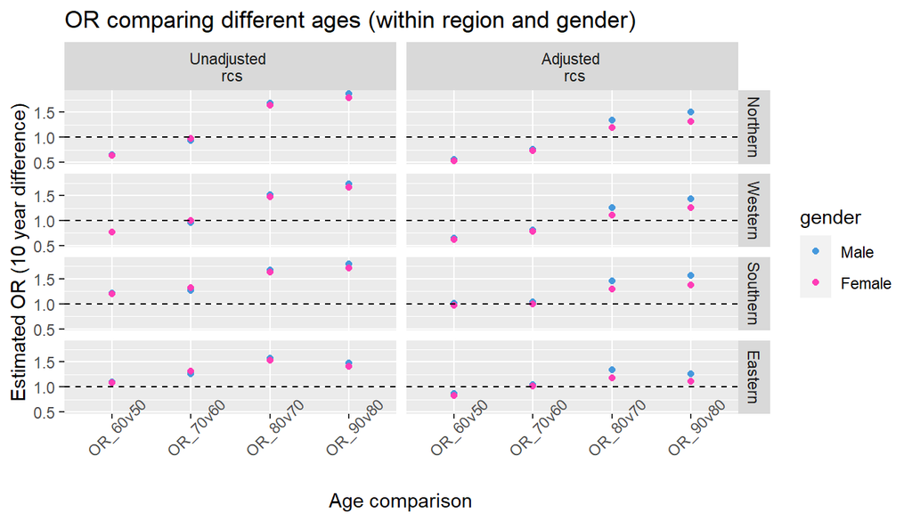

```r
pred.age.cat <- pred.age_all %>% filter(age1==0 | age1==10 | age1==20 | age1==30 | age1==40) %>% group_by(gender, region, model) %>% arrange(age1) %>% summarise(p_50=fit[1], p_60=fit[2], p_70=fit[3], p_80=fit[4], p_90=fit[5],
                                                                                                                                                           OR_60v50=(p_60/(1-p_60))/(p_50/(1-p_50)),                                                                                                     OR_70v60=(p_70/(1-p_70))/(p_60/(1-p_60)),                                                                                                     OR_80v70=(p_80/(1-p_80))/(p_70/(1-p_70)),
            OR_90v80=(p_90/(1-p_90))/(p_80/(1-p_80))
                                                                                                                                                           ) %>% arrange(region, gender)

pred.age.cat.melt <- melt(pred.age.cat, id.vars=c("gender", "region", "model"), measure.vars=c("OR_60v50",  "OR_70v60", "OR_80v70", "OR_90v80"))

pred.age.cat.melt <- pred.age.cat.melt  %>% mutate(model=factor(model, levels=c("Unadjusted \n rcs", "Adjusted \n rcs")))

pred.age.cat.unadjusted <- pred.age.cat.melt

ggplot(pred.age.cat.melt, aes(variable, value, color=gender)) + geom_point() + facet_grid(region~model)+
  labs(y="Estimated OR (10 year difference)" , x ="Age comparison")+geom_hline(yintercept = 1, lty=2) +  scale_color_manual(values=c("#4699dd","#ff3db7" )) + theme(axis.text.x = element_text(angle = 45)) + ggtitle("OR comparing different ages (within region and gender)")
```

```r
ggsave("FigDepression_OR_age_rcs.png", device="png", path = "figures" , scale=.75)
```

Within countries, the OR estimated for men and women comparing the same age categories were very similar in the unadjusted analysis, despite the presence of all the two-way interactions between age, gender and country. In the adjusted analysis the differences between genders appeared when we evaluated the effect of age after 70, where for men there was a larger increase in OR compared to women.

The OR were >1 after 70, below 1 for Nordic and Western region until 70.

##### 3.3.1.2.2 Estimated OR for depression for the comparison of genders (by country and fixed age)

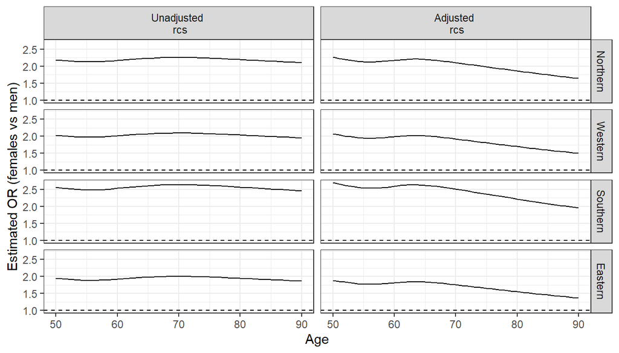

```r
#OR comparing genders - by age and country
pred.gender.cat <- pred.age_all %>% #filter(age1==0 | age1==10 | age1==20 | age1==30 | age1==40) %>%
  group_by(age1, region, model) %>% arrange(age1) %>% summarise(p_M=fit[1], p_F=fit[2], OR=p_F/(1-p_F)/(p_M/(1-p_M)))


pred.gender.cat.melt.gender <- melt(pred.gender.cat, id.vars=c("age1", "region", "model"), measure.vars=c("OR"))



pred.gender.cat.melt.gender<- pred.gender.cat.melt.gender  %>% mutate(model=factor(model, levels=c("Unadjusted \n rcs", "Adjusted \n rcs")))


pred.gender.cat.gender.unadjusted  <- pred.gender.cat.melt.gender

ggplot(pred.gender.cat.melt.gender, aes(age1+50, value)) + geom_line() +
  facet_grid(region~model)+ labs(y="Estimated OR (females vs men)" , x ="Age")+geom_hline(yintercept = 1, lty=2) +  scale_color_manual(values=c("#4699dd","#ff3db7" )) + theme(axis.text.x = element_text(angle = 45)) + theme_bw()
```

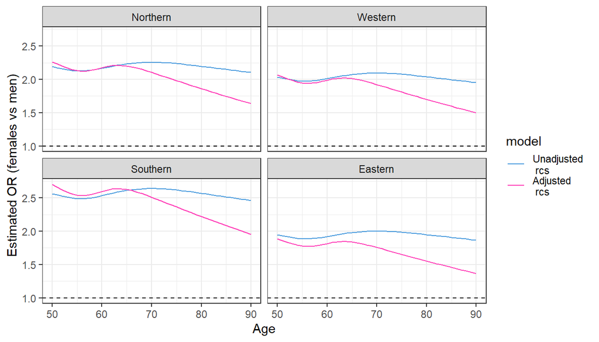

```r
ggsave("FigDepression_OR_gender_rcs.png", device="png", path = "figures" , scale=.75)




ggplot(pred.gender.cat.melt.gender, aes(age1+50, value, color=model)) + geom_line() +
  facet_wrap(region~., ncol=2)+ labs(y="Estimated OR (females vs men)" , x ="Age")+geom_hline(yintercept = 1, lty=2) +  scale_color_manual(values=c("#4699dd","#ff3db7" )) + theme(axis.text.x = element_text(angle = 45)) + theme_bw()
```

```r
ggsave("FigDepression_OR_gender_rcs_B.png", device="png", path = "figures" , scale=.75)
```

The estimated OR for depression for females vs men within countries was quite stable across ages in the unadjusted model, while thy showed a steady decline after 65, when the difference between genders diminished. The largest differences between genders were seen in the Southern region, the smallest difference was estimated in the Eastern region.